# Bay of Biscay and the Iberian Coast

WKTRADE 3 - April 2021

**Assessment sheet for Bay of Biscay and the Iberian Coast sub-region and for six subdivisions**

## Bay of Biscay and the Iberian Coast

### Summary

The physical disturbance pressures from mobile bottom-contacting fishing gears varies spatially in the Bay of Biscay and the Iberian Coast sub-region with 83% of the grid cells (I-2), and 66% of the surface area (I-3) being fished on average per year for the period 2013-2018 (Table 1) at depths <200m. Fishing is very aggregated with 90% of the pressure occurring in 47% of grid cells (I-4). In deeper areas, fishing is less intense. 81% of the grid cells (I-2), and 55% of the surface area (I-3) being fished on average per year for the period 2013-2018 (Table 1) at depths from 200 to 800m. Very little fishing occurs >800m depth.

The ICES methods for computing impact are not available at the moment in the region and therefore this part of the analysis has not been completed.

Maps of spatial distribution of intensity, economic value and weight of fisheries landings are shown in Figure 1, although the map of economic value seems incomplete in the Iberian coast. It is evident from the weight map that there is a mistake in the values for the region, and weights are not presented in further analyses.

#### Table 1

Table 1. Pressure and impact indicators for 2013-2018

| Indicators | 0 to 200 m | 200 to 800 m | more than 800 m |
| --- | --- | --- | --- |
| Average intensity (I-1) | 2.63 | 1.89 | 0.01 |
| Proportion of area in fished cells (I-2) | 0.83 | 0.81 | 0.04 |
| Proportion of area fished per year (I-3) | 0.66 | 0.55 | 0.00 |
| Smallest prop. of area in fished cells with 90% of fishing effort (I-4) | 0.47 | 0.38 | 0.01 |
| Proportion of area in unfished cells (I-5) | 0.17 | 0.19 | 0.96 |
| Average PD impact (I-6) | NA | NA | NA |
| Average L1 impact (I-6) | NA | NA | NA |
| Proportion of area with PD impact < 0.2 (I-7) | NA | NA | NA |
| Proportion of area with L1 impact < 0.2 (I-7) | NA | NA | NA |

#### Figure 1

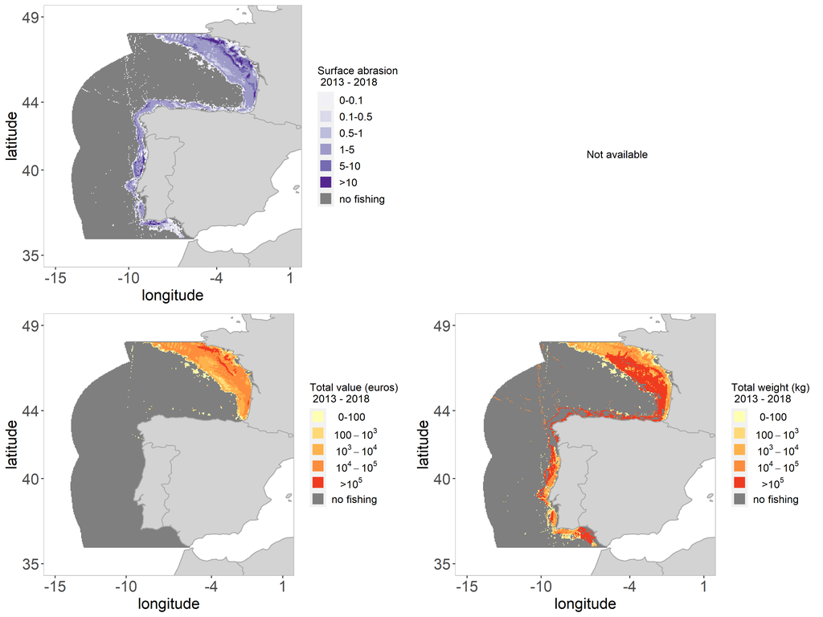

**Figure 1 Geographic distribution of surface abrasion, seabed sensitivity (not shown) and total value and weight from mobile bottom-contacting gear. The maps of surface abrasion, value and weight show the average per year for 2013-2018**

### Pressure

The distribution of fishing intensity in the Bay of Biscay and the Iberian Coast has a strong spatial variation (Figure 2). Areas of higher intensity occur in the shallower part of the French Bay of Biscay, and across the shelf break of the wester Iberian peninsula, mainly in areas of Galicia and central and south Portugal. Areas with lower intensity occur in central Cantabrian Sea and in the Gulf of Cadiz.

The proportion of area subject to fishing pressure differs between broad-scale habitats and is highest in offshore circalittoral mud (97% of grid cells fished) and offshore circalittoral sand (96% of grid cells fished) and some other less extensive habitats (Table 2). Fishing intensity is highest in offshore circalittoral mixed sediment (average intensity = 6.25 year-1) and circalittoral coarse sediment (average intensity = 6.08 year-1).

Total fishing intensity is largely unchanged over time (Figure 3). There is a large increase in intensity in offshore circalittoral sand and upper bathyal sediment in the period 2012-2014, which may be due to erroneous data. Fishing intensity is relatively stable over time in circalittoral sand and offshore circalittoral coarse sediment. The average trawling intensity is more variable over time than the proportion of area fished (Figure 3, compare left and middle panel). This shows that changes in intensity have not affected the spatial distribution of the footprint much.

#### Figure 2

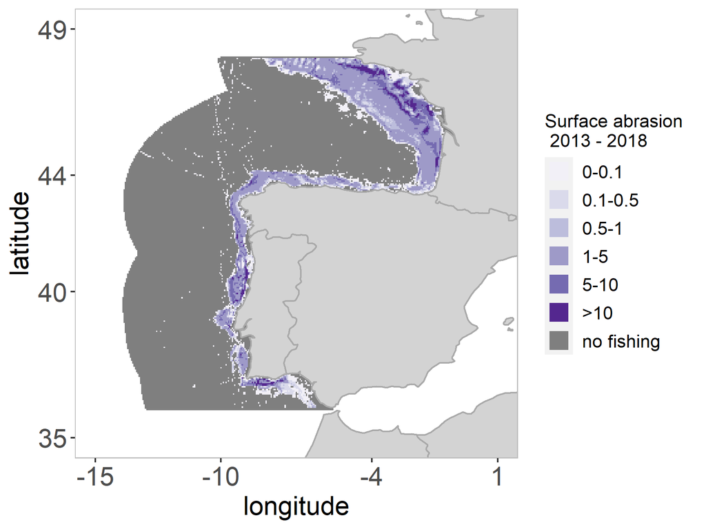

**Figure 2 Surface abrasion, Swept Area Ratio, by mobile bottom-contacting gears (year-1), averaged for the 2013-2018 six-year cycle**

#### Table 2

Table 2 Overview of pressure indicators of all mobile bottom-contacting gears per broad-scale habitat averaged for 2013-2018. I refers to the indicators in Table 1.

| MSFD broad habitat type | Extent of habitat (1000 km<sup>2</sup>) | Number of grid cells | Landings 1000 tonnes | Value 10<sup>6</sup> euro | Swept area 1000 km<sup>2</sup> | Average intensity (I-1) | Prop. of area in fished grid cells (I-2) | Prop. of area fished per year (I-3) | Smallest prop. of area with 90% of fishing effort (I-4) |
| --- | --- | --- | --- | --- | --- | --- | --- | --- | --- |
| Offshore circalittoral mud | 31.94 | 2741 | NA | NA | 118.58 | 3.71 | 0.97 | 0.87 | 0.45 |
| Offshore circalittoral sand | 34.91 | 3107 | NA | NA | 81.61 | 2.34 | 0.96 | 0.86 | 0.47 |
| Upper bathyal sediment | 36.76 | 2628 | NA | NA | 54.73 | 1.49 | 0.73 | 0.43 | 0.25 |
| Circalittoral coarse sediment | 8.77 | 1304 | NA | NA | 53.33 | 6.08 | 0.96 | 0.83 | 0.24 |
| Circalittoral sand | 16.56 | 2141 | NA | NA | 46.20 | 2.79 | 0.80 | 0.57 | 0.21 |
| Offshore circalittoral coarse sediment | 12.53 | 1519 | NA | NA | 30.27 | 2.42 | 0.98 | 0.89 | 0.44 |
| Offshore circalittoral mixed sediment | 3.47 | 733 | NA | NA | 21.69 | 6.25 | 0.98 | 0.93 | 0.31 |
| Circalittoral mixed sediment | 2.99 | 519 | NA | NA | 15.64 | 5.23 | 0.81 | 0.51 | 0.11 |
| Offshore circalittoral rock and biogenic reef | 7.26 | 1406 | NA | NA | 14.47 | 1.99 | 0.91 | 0.72 | 0.36 |
| Upper bathyal sediment or Upper bathyal rock and biogenic reef | 21.70 | 1491 | NA | NA | 11.12 | 0.51 | 0.41 | 0.18 | 0.11 |
| Circalittoral mud | 6.41 | 1114 | NA | NA | 7.81 | 1.22 | 0.71 | 0.32 | 0.13 |
| Circalittoral rock and biogenic reef | 7.05 | 1483 | NA | NA | 4.86 | 0.69 | 0.74 | 0.29 | 0.19 |
| Upper bathyal rock and biogenic reef | 1.74 | 411 | NA | NA | 1.61 | 0.92 | 0.53 | 0.32 | 0.18 |
| Lower bathyal sediment or Lower bathyal rock and biogenic reef | 36.17 | 2508 | NA | NA | 0.60 | 0.02 | 0.08 | 0.01 | 0.02 |
| Infralittoral sand | 2.58 | 1030 | NA | NA | 0.47 | 0.18 | 0.37 | 0.08 | 0.04 |
| Unknown | 0.56 | 888 | NA | NA | 0.42 | 0.75 | 0.41 | 0.25 | 0.02 |
| Infralittoral rock and biogenic reef | 2.08 | 943 | NA | NA | 0.18 | 0.09 | 0.40 | 0.06 | 0.11 |
| Lower bathyal sediment | 12.10 | 1281 | NA | NA | 0.15 | 0.01 | 0.22 | 0.01 | 0.09 |
| Infralittoral mud | 0.73 | 426 | NA | NA | 0.11 | 0.15 | 0.35 | 0.06 | 0.03 |
| Abyssal | 513.94 | 23384 | NA | NA | 0.11 | 0.00 | 0.02 | 0.00 | 0.01 |
| Infralittoral coarse sediment | 0.51 | 387 | NA | NA | 0.02 | 0.05 | 0.46 | 0.04 | 0.13 |
| Infralittoral mixed sediment | 0.37 | 164 | NA | NA | 0.02 | 0.04 | 0.29 | 0.04 | 0.10 |
| Lower bathyal rock and biogenic reef | 0.50 | 79 | NA | NA | 0.00 | 0.00 | 0.09 | 0.00 | 0.08 |

#### Figure 3

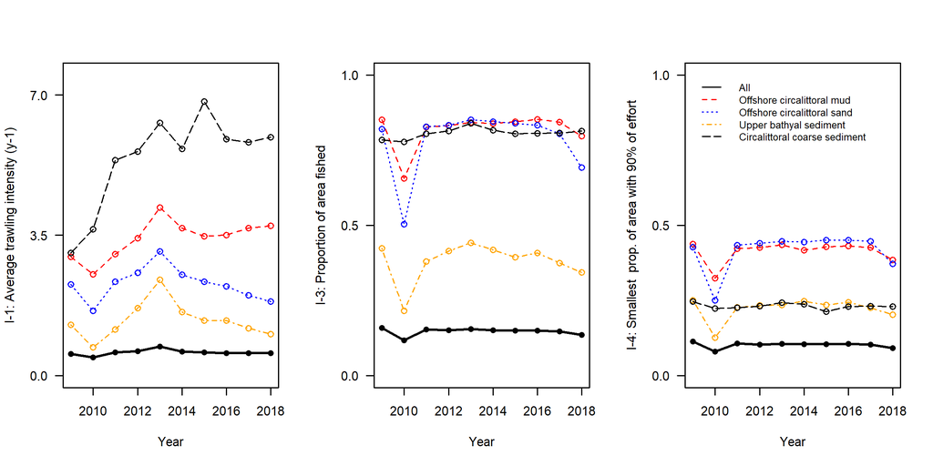

**Figure 3. Time series of (a) mean fishing intensity (surface abrasion), (b) proportion of the surface area of the seafloor fished, (c) aggregation of fishing (proportion of the surface area with 90% of the fishing effort) by habitat. Results represent vessels over 15m (2009-2011) and vessels over 12m (2012-2018).**

#### Figure 4

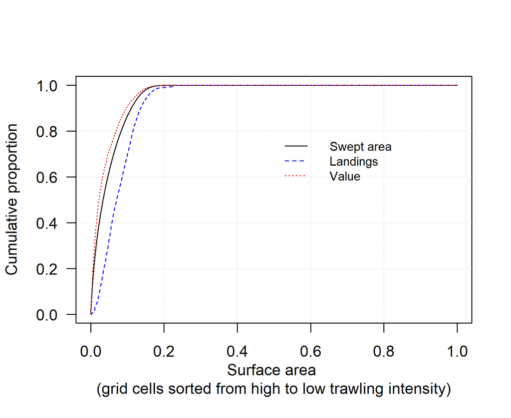

**Figure 4. Cumulative proportion of the swept area, landings and value. Grid cells were sorted from highest to lowest fishing intensity and include non-fished cells. The results are for all mobile bottom-contacting gears based on averaged fishing data per c-square from 2013-2018.**

### Core fishing grounds

No information available

### Fishing by métier

Area swept is estimated for the grid cells that were fished by one MBCG métier, ignoring cells fished by other métiers (Table 3).

#### Table 3

Table 3. Overview of area fished (sum of swept area), landings and value for the different metiers. Area fished in 1000 km2, weight of landings in 1000 tonnes, value of landings in 10^6 euro.

|  | DRB_MOL | OT_CRU | OT_DMF | OT_MI | OT_SPF | SDN_DMF | SSC_DMF | TBB_CRU | TBB_DMF | TBB_MOL |
| --- | --- | --- | --- | --- | --- | --- | --- | --- | --- | --- |
| Area swept (1000 km2) | 0.06 | 165.45 | 219.93 | 23.96 | 1.95 | 50.46 | 0 | 0 | 3.14 | 0 |
| Landings (1000 tonnes) | NA | NA | NA | NA | NA | NA | NA | NA | NA | NA |
| Value (10^6 euro) | NA | NA | NA | NA | NA | NA | NA | NA | NA | NA |
| Landings (1000 tonnes)/Area swept (1000 km2) | NA | NA | NA | NA | NA | NA | NA | NA | NA | NA |
| Value (10^6 euro)/Area swept (1000 km2) | NA | NA | NA | NA | NA | NA | NA | NA | NA | NA |

### Impact

No information available

### Management scenarios

No information available on value/weight of landings.

#### Overview all MSFD habitats

Fishing effort consequences, as a % relative to total swept area, of protecting a certain fraction of each broad habitat type sorted from low to high fished c-squares

| MSFD broad habitat type | Extent of habitat 1000 km<sup>2</sup> | 0.05 | 0.1 | 0.2 | 0.3 | 0.4 | 0.5 | 0.6 | 0.7 | 0.8 | 0.9 |
| --- | --- | --- | --- | --- | --- | --- | --- | --- | --- | --- | --- |
| Offshore circalittoral mud | 31.94 | <0.1 | 0.3 | 3.2 | 8.4 | 14.6 | 21.3 | 29.8 | 39.7 | 52.3 | 68.8 |
| Offshore circalittoral sand | 34.91 | <0.1 | 0.9 | 4.7 | 10.3 | 17.6 | 26.3 | 36.0 | 47.0 | 60.0 | 76.4 |
| Upper bathyal sediment | 36.76 | 0.0 | 0.0 | 0.0 | <0.1 | 0.2 | 1.1 | 3.9 | 11.1 | 26.6 | 51.7 |
| Circalittoral coarse sediment | 8.77 | <0.1 | <0.1 | 0.9 | 4.2 | 10.3 | 19.1 | 29.2 | 39.9 | 53.8 | 72.2 |
| Circalittoral sand | 16.56 | 0.0 | 0.0 | <0.1 | <0.1 | 0.8 | 4.1 | 12.9 | 26.0 | 41.2 | 62.9 |
| Offshore circalittoral coarse sediment | 12.53 | 0.6 | 2.5 | 7.5 | 12.9 | 19.1 | 27.4 | 36.0 | 46.3 | 58.8 | 73.7 |
| Offshore circalittoral mixed sediment | 3.47 | 0.2 | 1.0 | 5.1 | 10.5 | 17.0 | 24.7 | 33.8 | 45.2 | 59.7 | 76.9 |
| Circalittoral mixed sediment | 2.99 | 0.0 | 0.0 | <0.1 | <0.1 | 0.3 | 1.0 | 3.9 | 15.8 | 32.6 | 58.4 |
| Offshore circalittoral rock and biogenic reef | 7.26 | 0.0 | <0.1 | 1.2 | 5.5 | 11.3 | 19.3 | 29.3 | 40.0 | 54.6 | 70.9 |
| Upper bathyal sediment or Upper bathyal rock and biogenic reef | 21.7 | 0.0 | 0.0 | 0.0 | 0.0 | 0.0 | 0.0 | <0.1 | 0.5 | 3.5 | 19.3 |
| Circalittoral mud | 6.41 | 0.0 | 0.0 | 0.0 | <0.1 | <0.1 | 0.3 | 1.0 | 4.7 | 16.1 | 43.1 |
| Circalittoral rock and biogenic reef | 7.05 | 0.0 | 0.0 | 0.0 | <0.1 | 0.6 | 2.1 | 5.4 | 10.6 | 22.5 | 42.2 |
| Upper bathyal rock and biogenic reef | 1.74 | 0.0 | 0.0 | 0.0 | 0.0 | 0.0 | <0.1 | 1.1 | 7.5 | 24.0 | 56.9 |
| Lower bathyal sediment or Lower bathyal rock and biogenic reef | 36.17 | 0.0 | 0.0 | 0.0 | 0.0 | 0.0 | 0.0 | 0.0 | 0.0 | 0.0 | 0.0 |
| Infralittoral sand | 2.58 | 0.0 | 0.0 | 0.0 | 0.0 | 0.0 | 0.0 | 0.0 | 0.1 | 1.3 | 6.3 |
| Unknown | 0.56 | 0.0 | 0.0 | 0.0 | 0.0 | 0.0 | 0.0 | <0.1 | 1.7 | 15.5 | 41.3 |
| Infralittoral rock and biogenic reef | 2.08 | 0.0 | 0.0 | 0.0 | 0.0 | 0.0 | 0.0 | <0.1 | 0.8 | 4.6 | 19.9 |
| Lower bathyal sediment | 12.1 | 0.0 | 0.0 | 0.0 | 0.0 | 0.0 | 0.0 | 0.0 | 0.0 | <0.1 | 5.4 |
| Infralittoral mud | 0.73 | 0.0 | 0.0 | 0.0 | 0.0 | 0.0 | 0.0 | 0.0 | <0.1 | 1.6 | 7.7 |
| Abyssal | 513.94 | 0.0 | 0.0 | 0.0 | 0.0 | 0.0 | 0.0 | 0.0 | 0.0 | 0.0 | 0.0 |
| Infralittoral coarse sediment | 0.51 | 0.0 | 0.0 | 0.0 | 0.0 | 0.0 | 0.0 | 0.8 | 6.6 | 19.4 | 46.5 |
| Infralittoral mixed sediment | 0.37 | 0.0 | 0.0 | 0.0 | 0.0 | 0.0 | 0.0 | 0.0 | 0.0 | 1.1 | 14.2 |
| Lower bathyal rock and biogenic reef | 0.5 | 0.0 | 0.0 | 0.0 | 0.0 | 0.0 | 0.0 | 0.0 | 0.0 | 0.0 | 0.0 |

## Bay of Biscay - shallow

### Summary

The physical disturbance pressures from mobile bottom-contacting fishing gears varies spatially in the “Bay of Biscay shallow” subdivision with 92% of the grid cells (I-2), and 80% of the surface area (I-3), in the depth zone 0-200m, being fished on average per year for the period 2013-2018 (Table 1). Fishing is relatively aggregated with 90% of the pressure occurring in 56% of grid cells (I-4).

The ICES methods for computing impact are not available at the moment in the region and therefore this part of the analysis has not been completed.

Maps of spatial distribution of intensity, seafloor sensitivity and economic value and weight of fisheries landings are shown in Figure 1. It is evident from the weight map that there is a mistake in the values for the region, and weights are not presented in further analyses.

#### Table 1

Table 1. Pressure and impact indicators for 2013-2018

| Indicators | 0 to 200 m | 200 to 800 m | more than 800 m |
| --- | --- | --- | --- |
| Average intensity (I-1) | 3.33 | NA | NA |
| Proportion of area in fished cells (I-2) | 0.92 | NA | NA |
| Proportion of area fished per year (I-3) | 0.80 | NA | NA |
| Smallest prop. of area in fished cells with 90% of fishing effort (I-4) | 0.56 | NA | NA |
| Proportion of area in unfished cells (I-5) | 0.08 | NA | NA |
| Average PD impact (I-6) | NA | NA | NA |
| Average L1 impact (I-6) | NA | NA | NA |
| Proportion of area with PD impact < 0.2 (I-7) | NA | NA | NA |
| Proportion of area with L1 impact < 0.2 (I-7) | NA | NA | NA |

#### Figure 1

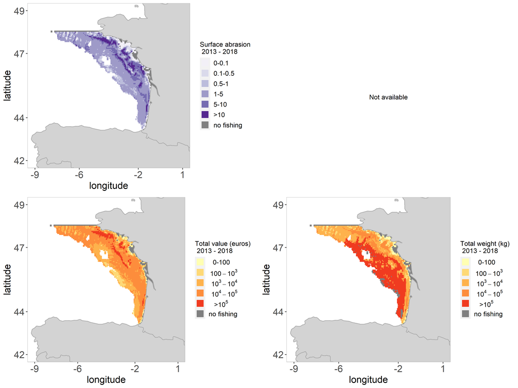

**Figure 1 Geographic distribution of surface abrasion, seabed sensitivity (not shown) and total value and weight from mobile bottom-contacting gear. The maps of surface abrasion, value and weight show the average per year for 2013-2018**

### Pressure

The distribution of fishing intensity in the “Bay of Biscay shallow” has a strong spatial variation (Figure 2). Areas of higher intensity occur in areas close to the coast, mainly in the central and norther part of the region. Areas with lower intensity occur in the western part of the region, in the deepest part of the study area.

The proportion of area subject to fishing pressure differs between broad-scale habitats and is highest in several broad habitat such as offshore circalittoral mud (100% of grid cells fished), offshore circalittoral sand (98%) and offshore circalittoral coarse sediment (99%) (Table 2). Fishing intensity is highest in offshore circalittoral mixed sediments (average intensity = 8.36 year-1) and circalittoral coarse sediment (average intensity = 6.47 year-1).

Total fishing intensity shows an increase over time (Figure 3). The mean fishing intensity increased during the study period for the offshore circalittoral mud and circalittoral sand, it keeps constant for offshore circalittoral coarse sediment and decreased for offshore circalittoral sand. The average trawling intensity is more variable over time (showing an increase) than the proportion of area fished (Figure 3, compare left and middle panel). This shows that changes in intensity have not affected the spatial distribution of the footprint much.

#### Figure 2

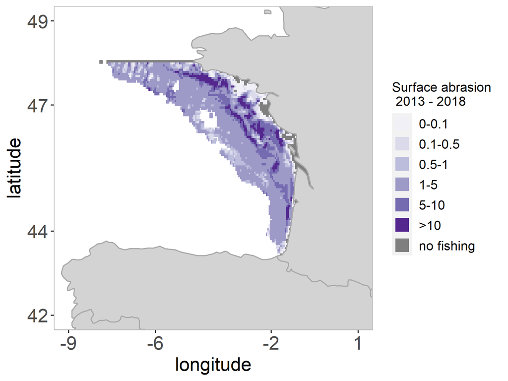

**Figure 2 Surface abrasion, Swept Area Ratio, by mobile bottom-contacting gears (year-1), averaged for the 2013-2018 six-year cycle**

#### Table 2

Table 2 Overview of pressure indicators of all mobile bottom-contacting gears per broad-scale habitat averaged for 2013-2018. I refers to the indicators in Table 1.

| MSFD broad habitat type | Extent of habitat (1000 km<sup>2</sup>) | Number of grid cells | Landings 1000 tonnes | Value 10<sup>6</sup> euro | Swept area 1000 km<sup>2</sup> | Average intensity (I-1) | Prop. of area in fished grid cells (I-2) | Prop. of area fished per year (I-3) | Smallest prop. of area with 90% of fishing effort (I-4) |
| --- | --- | --- | --- | --- | --- | --- | --- | --- | --- |
| Offshore circalittoral mud | 15.67 | 1234 | NA | 34.14 | 72.82 | 4.65 | 1.00 | 0.97 | 0.53 |
| Circalittoral coarse sediment | 8.23 | 1055 | NA | 20.31 | 53.18 | 6.47 | 0.98 | 0.87 | 0.29 |
| Offshore circalittoral sand | 22.06 | 1564 | NA | 14.05 | 51.71 | 2.34 | 0.98 | 0.90 | 0.55 |
| Circalittoral sand | 10.07 | 1071 | NA | 14.21 | 40.55 | 4.03 | 0.97 | 0.83 | 0.36 |
| Offshore circalittoral coarse sediment | 9.18 | 996 | NA | 7.31 | 24.57 | 2.68 | 0.99 | 0.93 | 0.49 |
| Offshore circalittoral mixed sediment | 2.05 | 293 | NA | 10.02 | 17.12 | 8.36 | 1.00 | 0.99 | 0.44 |
| Circalittoral mud | 2.67 | 534 | NA | 2.13 | 5.41 | 2.03 | 0.92 | 0.59 | 0.22 |
| Offshore circalittoral rock and biogenic reef | 2.09 | 377 | NA | 2.60 | 5.38 | 2.57 | 0.99 | 0.93 | 0.48 |
| Circalittoral rock and biogenic reef | 2.94 | 614 | NA | 1.68 | 3.16 | 1.08 | 0.94 | 0.44 | 0.27 |
| Circalittoral mixed sediment | 0.24 | 80 | NA | 0.37 | 1.10 | 4.58 | 0.97 | 0.91 | 0.30 |
| Upper bathyal sediment | 0.25 | 54 | NA | 0.12 | 0.55 | 2.17 | 1.00 | 0.78 | 0.43 |
| Infralittoral sand | 0.72 | 375 | NA | 0.19 | 0.37 | 0.51 | 0.65 | 0.17 | 0.05 |
| Infralittoral rock and biogenic reef | 0.85 | 391 | NA | 0.07 | 0.12 | 0.14 | 0.57 | 0.09 | 0.13 |
| Unknown | 0.20 | 403 | NA | 0.05 | 0.11 | 0.58 | 0.62 | 0.35 | 0.04 |
| Infralittoral mud | 0.37 | 199 | NA | 0.04 | 0.09 | 0.25 | 0.36 | 0.06 | 0.03 |
| Infralittoral coarse sediment | 0.36 | 288 | NA | 0.03 | 0.02 | 0.05 | 0.57 | 0.04 | 0.15 |
| Infralittoral mixed sediment | 0.06 | 50 | NA | 0.00 | 0.00 | 0.04 | 0.37 | 0.04 | 0.08 |
| Upper bathyal sediment or Upper bathyal rock and biogenic reef | 0.00 | 1 | NA | 0.00 | 0.00 | 1.40 | 1.00 | 1.00 | NA |

#### Figure 3

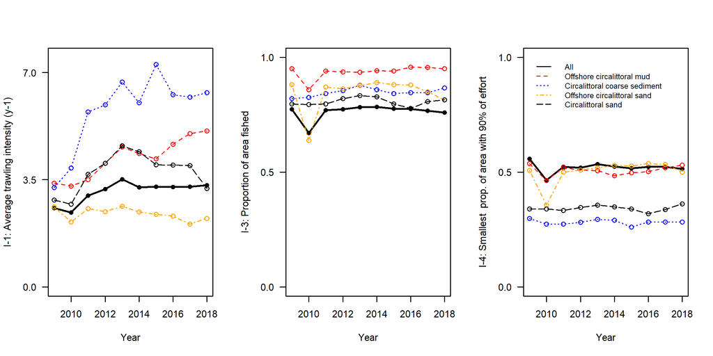

**Figure 3. Time series of (a) mean fishing intensity (surface abrasion), (b) proportion of the surface area of the seafloor fished, (c) aggregation of fishing (proportion of the surface area with 90% of the fishing effort) by habitat. Results represent vessels over 15m (2009-2011) and vessels over 12m (2012-2018).**

#### Figure 4

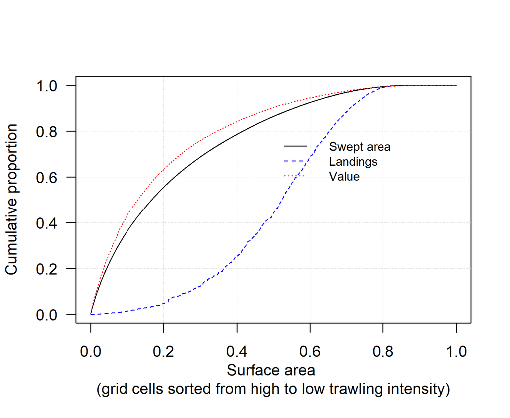

**Figure 4. Cumulative proportion of the swept area, landings and value. Grid cells were sorted from highest to lowest fishing intensity and include non-fished cells. The results are for all mobile bottom-contacting gears based on averaged fishing data per c-square from 2013-2018.**

### Core fishing grounds

Core fishing grounds are defined as the c-squares with the 90% highest value of landings in the VMS data. Figure 5 shows the number of years c-squares are within the 90% highest value by métier. If fishing in a métier occurs in the same c-square every year with high value of landings, the rightmost bar in Figure 5 and 6 will be high, meaning that the c-square is within the 90% highest value of landings every year during the period 2013-2018. If a c-square is only within the 90% highest value in one year, it will end up in the bar at the left. Figure 6 shows the percentage area overlap between the 90% highest value per year and the reference fishing ground. Both figures highlight that the fisheries for small pelagic fish (OT_SPF) has the highest variation in space. Figure 7 illustrates the relationship between area fished in percent and the cumulated value of landings, sorted from the c-squares with highest value fisheries. The curves are generally starting steeply, illustrating the concentration of the fisheries at fishing grounds and the curves are ending horizontally, illustrating the peripheral fisheries going on outside the main fishing grounds. In this region, two metier (OT_DMF and TBB_DMF) show a less steeply start, showing that these fisheries are less aggregated than the others.

#### Figure 5

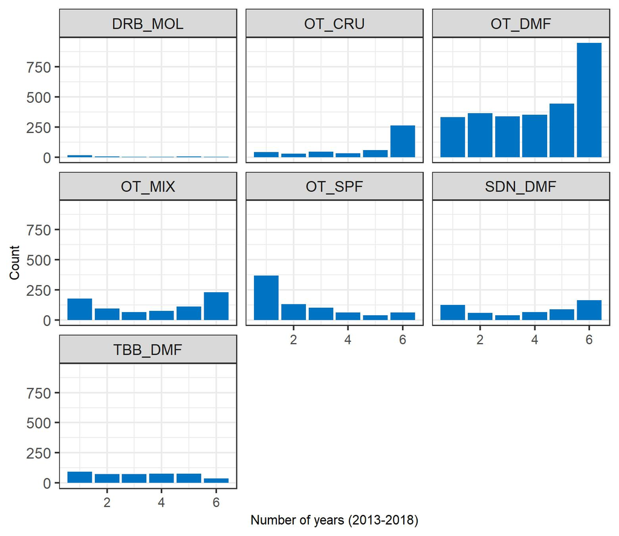

**Figure 5. Number of years c-squares are within the 90% core fishing grounds by metier during the period 2013-2018**

#### Figure 6

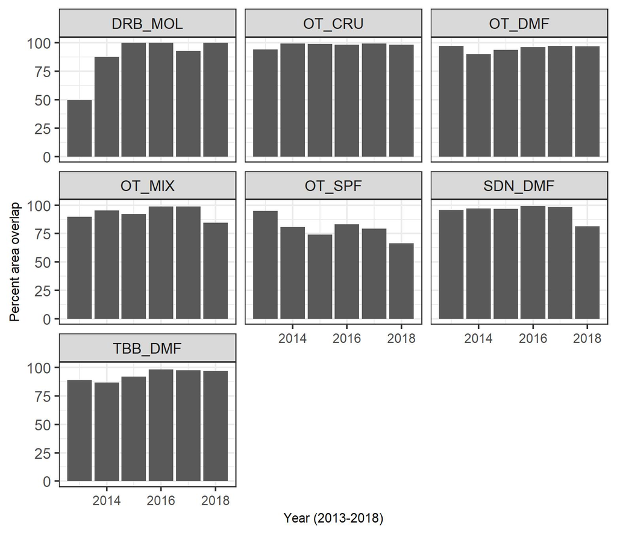

**Figure 6. Percentage area overlap between the 90% highest value per year and the reference core fishing ground**

#### Figure 7

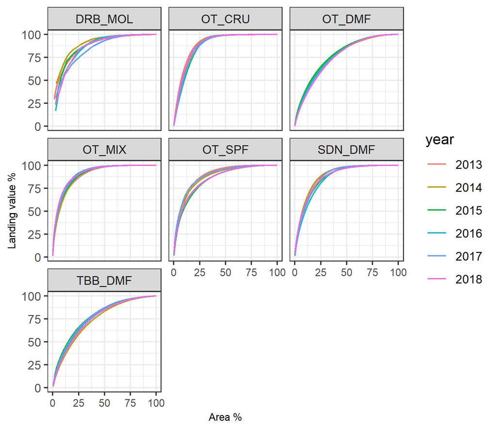

**Figure 7. Percent area fished vs. landings value (euro) by métier, coloured by year**

### Fishing by métier

Intensity, weight and value of landings are estimated for the grid cells that were fished by one MBCG métier, ignoring cells fished by other métiers (Table 3).

#### Table 3

Table 3. Overview of area fished (sum of swept area), landings and value for the different metiers. Area fished in 1000 km2, weight of landings in 1000 tonnes, value of landings in 10^6 euro.

|  | DRB_MOL | OT_CRU | OT_DMF | OT_MI | OT_SPF | SDN_DMF | SSC_DMF | TBB_CRU | TBB_DMF | TBB_MOL |
| --- | --- | --- | --- | --- | --- | --- | --- | --- | --- | --- |
| Area swept (1000 km2) | 0.01 | 64.51 | 134.08 | 23.92 | 1.85 | 49.29 | 0 | 0 | 3.13 | 0 |
| Landings (1000 tonnes) | NA | NA | NA | NA | NA | NA | NA | NA | NA | NA |
| Value (10^6 euro) | 0.15 | 41.34 | 36.75 | 16.46 | 1.13 | 9.31 | 0 | 0 | 2.45 | 0 |
| Landings (1000 tonnes)/Area swept (1000 km2) | NA | NA | NA | NA | NA | NA | NA | NA | NA | NA |
| Value (10^6 euro)/Area swept (1000 km2) | 22.48 | 0.64 | 0.27 | 0.69 | 0.61 | 0.19 | NA | NA | 0.78 | NA |

### Impact

No information available

### Management scenarios

The figures and tables below show one implementation of multi-purpose habitat management through reductions in effort and spatial closures for the four most extensive MSFD habitat types. They show only the changes in average unfished area since changes in impact and average values were not available for this region.

The analysis is based on the progressive removal of 5 to 99% of all MBCG fishing effort, starting from the c-squares with the lowest effort (corrected for the areal extent of the MSFD habitat within each c-square). Blue dots show the current situation and are used as reference. The % of unfished area in the reference is only based on grid cells that are unfished. Note that the fraction of grid cells above/below a certain impact threshold initially remains the same (not shown) as the removal of effort starts from the c-squares with the lowest effort that typically have low impact.

#### MSFD habitat - 1

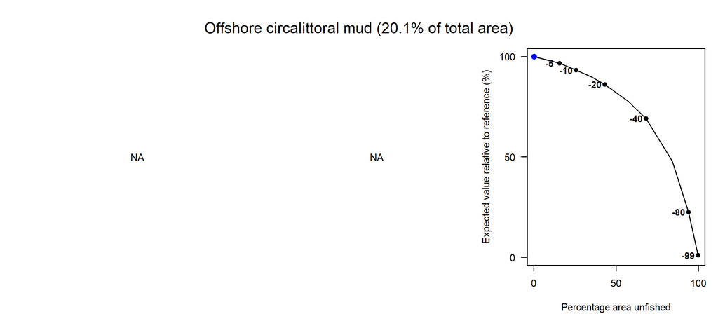

**Multi-purpose habitat management trade-off for the most extensive MSFD habitat type.**

Table presenting a similar overview as above, while including weight of landings

| Effort reduction (%) | Average PD impact | Average L1 impact | Area unfished (%) | Value (%) | Weight (%) |
| --- | --- | --- | --- | --- | --- |
| 0 | NA | NA | 0.15 | 100.00 | NA |
| 5 | NA | NA | 15.62 | 96.68 | NA |
| 10 | NA | NA | 25.74 | 93.21 | NA |
| 15 | NA | NA | 35.20 | 89.88 | NA |
| 20 | NA | NA | 43.14 | 86.14 | NA |
| 30 | NA | NA | 57.23 | 77.82 | NA |
| 40 | NA | NA | 68.18 | 69.18 | NA |
| 60 | NA | NA | 84.11 | 47.83 | NA |
| 80 | NA | NA | 93.94 | 22.57 | NA |
| 99 | NA | NA | 99.87 | 1.02 | NA |

#### MSFD habitat - 2

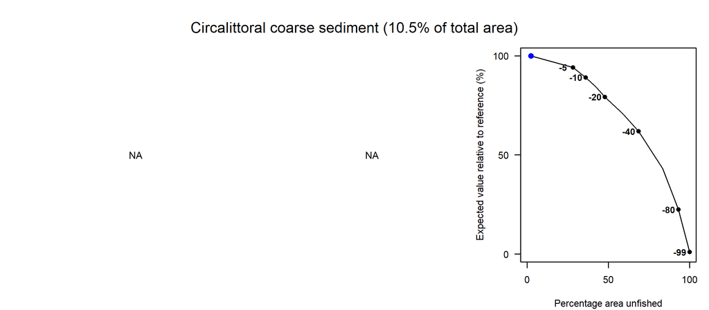

**Multi-purpose habitat management trade-off for the most extensive MSFD habitat type.**

Table presenting a similar overview as above, while including weight of landings

| Effort reduction (%) | Average PD impact | Average L1 impact | Area unfished (%) | Value (%) | Weight (%) |
| --- | --- | --- | --- | --- | --- |
| 0 | NA | NA | 2.33 | 100.00 | NA |
| 5 | NA | NA | 28.15 | 94.18 | NA |
| 10 | NA | NA | 36.07 | 89.15 | NA |
| 15 | NA | NA | 42.35 | 84.30 | NA |
| 20 | NA | NA | 47.80 | 79.32 | NA |
| 30 | NA | NA | 58.70 | 70.98 | NA |
| 40 | NA | NA | 68.59 | 61.96 | NA |
| 60 | NA | NA | 83.46 | 43.06 | NA |
| 80 | NA | NA | 93.17 | 22.45 | NA |
| 99 | NA | NA | 100.00 | 1.07 | NA |

#### MSFD habitat - 3

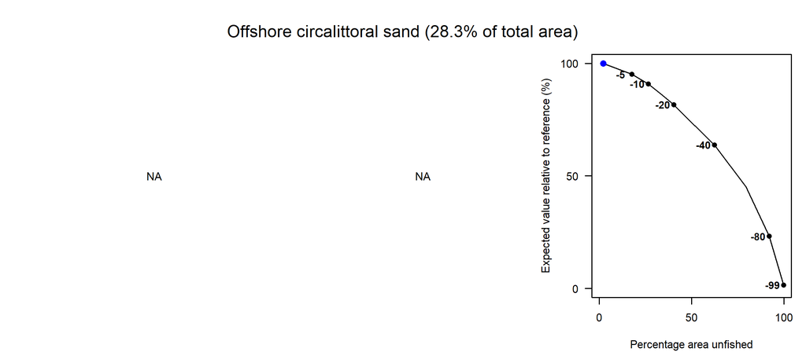

**Multi-purpose habitat management trade-off for the most extensive MSFD habitat type.**

Table presenting a similar overview as above, while including weight of landings

| Effort reduction (%) | Average PD impact | Average L1 impact | Area unfished (%) | Value (%) | Weight (%) |
| --- | --- | --- | --- | --- | --- |
| 0 | NA | NA | 2.12 | 100.00 | NA |
| 5 | NA | NA | 17.65 | 95.18 | NA |
| 10 | NA | NA | 26.57 | 90.94 | NA |
| 15 | NA | NA | 33.77 | 86.05 | NA |
| 20 | NA | NA | 40.41 | 81.70 | NA |
| 30 | NA | NA | 51.78 | 72.30 | NA |
| 40 | NA | NA | 62.37 | 63.83 | NA |
| 60 | NA | NA | 79.45 | 45.10 | NA |
| 80 | NA | NA | 91.95 | 23.27 | NA |
| 99 | NA | NA | 99.81 | 1.53 | NA |

#### MSFD habitat - 4

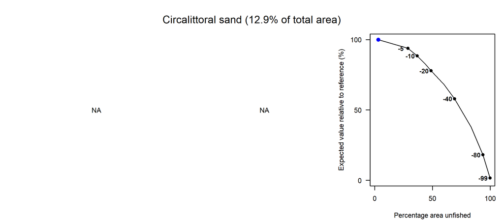

**Multi-purpose habitat management trade-off for the most extensive MSFD habitat type.**

Table presenting a similar overview as above, while including weight of landings

| Effort reduction (%) | Average PD impact | Average L1 impact | Area unfished (%) | Value (%) | Weight (%) |
| --- | --- | --- | --- | --- | --- |
| 0 | NA | NA | 3.12 | 100.00 | NA |
| 5 | NA | NA | 28.71 | 93.80 | NA |
| 10 | NA | NA | 36.80 | 88.42 | NA |
| 15 | NA | NA | 43.37 | 83.20 | NA |
| 20 | NA | NA | 48.73 | 77.87 | NA |
| 30 | NA | NA | 60.05 | 68.08 | NA |
| 40 | NA | NA | 69.19 | 58.02 | NA |
| 60 | NA | NA | 83.40 | 37.91 | NA |
| 80 | NA | NA | 93.66 | 18.18 | NA |
| 99 | NA | NA | 99.80 | 1.66 | NA |

#### Overview all MSFD habitats

Fishing effort consequences, as a % relative to total swept area, of protecting a certain fraction of each broad habitat type sorted from low to high fished c-squares

| MSFD broad habitat type | Extent of habitat 1000 km<sup>2</sup> | 0.05 | 0.1 | 0.2 | 0.3 | 0.4 | 0.5 | 0.6 | 0.7 | 0.8 | 0.9 |
| --- | --- | --- | --- | --- | --- | --- | --- | --- | --- | --- | --- |
| Offshore circalittoral mud | 15.67 | 1.1 | 2.7 | 7.1 | 12.2 | 18.0 | 24.7 | 32.6 | 42.3 | 53.9 | 71.0 |
| Circalittoral coarse sediment | 8.23 | <0.1 | 0.2 | 2.0 | 6.1 | 13.4 | 21.8 | 31.3 | 42.1 | 55.5 | 73.8 |
| Offshore circalittoral sand | 22.06 | 0.7 | 2.0 | 6.4 | 12.3 | 19.8 | 28.5 | 37.7 | 48.4 | 60.8 | 76.5 |
| Circalittoral sand | 10.07 | <0.1 | <0.1 | 1.7 | 5.8 | 12.4 | 21.3 | 30.1 | 41.2 | 54.7 | 72.3 |
| Offshore circalittoral coarse sediment | 9.18 | 1.6 | 4.0 | 9.1 | 14.1 | 21.3 | 28.8 | 37.1 | 48.0 | 59.1 | 74.3 |
| Offshore circalittoral mixed sediment | 2.05 | 1.7 | 3.9 | 8.8 | 15.8 | 24.3 | 32.3 | 41.5 | 53.8 | 67.4 | 83.4 |
| Circalittoral mud | 2.67 | 0.0 | <0.1 | 0.2 | 0.7 | 3.3 | 7.4 | 15.0 | 26.5 | 42.6 | 68.3 |
| Offshore circalittoral rock and biogenic reef | 2.09 | 2.0 | 6.0 | 14.0 | 19.1 | 26.7 | 33.8 | 43.4 | 54.2 | 64.0 | 77.6 |
| Circalittoral rock and biogenic reef | 2.94 | 0.0 | <0.1 | 0.4 | 1.6 | 4.3 | 7.5 | 11.4 | 20.7 | 33.6 | 51.8 |
| Circalittoral mixed sediment | 0.24 | <0.1 | 0.5 | 5.6 | 10.8 | 16.5 | 24.0 | 30.6 | 46.2 | 69.9 | 89.5 |
| Upper bathyal sediment | 0.25 | 1.4 | 2.7 | 4.9 | 8.6 | 14.9 | 26.1 | 34.7 | 42.5 | 61.4 | 80.9 |
| Infralittoral sand | 0.72 | 0.0 | 0.0 | 0.0 | 0.0 | <0.1 | <0.1 | 0.2 | 0.7 | 3.5 | 27.6 |
| Infralittoral rock and biogenic reef | 0.85 | 0.0 | 0.0 | 0.0 | 0.0 | 0.0 | <0.1 | 1.0 | 2.9 | 8.4 | 22.7 |
| Unknown | 0.2 | 0.0 | 0.0 | 0.0 | 0.0 | 0.2 | 1.0 | 6.4 | 25.8 | 37.5 | 69.4 |
| Infralittoral mud | 0.37 | 0.0 | 0.0 | 0.0 | 0.0 | 0.0 | 0.0 | 0.0 | 0.1 | 0.9 | 3.1 |
| Infralittoral coarse sediment | 0.36 | 0.0 | 0.0 | 0.0 | 0.0 | 0.0 | 0.9 | 5.8 | 17.4 | 32.7 | 50.4 |
| Infralittoral mixed sediment | 0.06 | 0.0 | 0.0 | 0.0 | 0.0 | 0.0 | 0.0 | 0.0 | 0.9 | 7.9 | 11.7 |
| Upper bathyal sediment or Upper bathyal rock and biogenic reef | 0 | 100.0 | 100.0 | 100.0 | 100.0 | 100.0 | 100.0 | 100.0 | 100.0 | 100.0 | 100.0 |

Fishing value consequences, as a % relative to total value, of protecting a certain fraction of each broad habitat type sorted from low to high fished c-squares

| MSFD broad habitat type | Extent of habitat 1000 km<sup>2</sup> | 0.05 | 0.1 | 0.2 | 0.3 | 0.4 | 0.5 | 0.6 | 0.7 | 0.8 | 0.9 |
| --- | --- | --- | --- | --- | --- | --- | --- | --- | --- | --- | --- |
| Offshore circalittoral mud | 15.67 | 0.7 | 1.9 | 4.9 | 8.1 | 12.5 | 17.5 | 24.4 | 33.0 | 45.1 | 66.3 |
| Circalittoral coarse sediment | 8.23 | <0.1 | 0.3 | 2.6 | 6.9 | 14.2 | 22.3 | 30.3 | 40.1 | 52.5 | 71.3 |
| Offshore circalittoral sand | 22.06 | 0.8 | 2.2 | 6.0 | 11.2 | 18.2 | 26.5 | 34.3 | 43.5 | 55.7 | 73.0 |
| Circalittoral sand | 10.07 | <0.1 | 0.2 | 2.4 | 7.2 | 14.3 | 23.6 | 32.1 | 43.0 | 56.5 | 75.1 |
| Offshore circalittoral coarse sediment | 9.18 | 1.9 | 4.3 | 9.5 | 14.3 | 21.9 | 29.2 | 37.2 | 48.1 | 59.5 | 73.1 |
| Offshore circalittoral mixed sediment | 2.05 | 1.2 | 3.0 | 6.9 | 13.8 | 22.9 | 31.0 | 40.2 | 54.0 | 66.9 | 83.0 |
| Circalittoral mud | 2.67 | 0.0 | <0.1 | 0.4 | 1.1 | 4.5 | 9.6 | 18.3 | 29.6 | 45.5 | 69.8 |
| Offshore circalittoral rock and biogenic reef | 2.09 | 1.7 | 5.3 | 13.4 | 17.1 | 24.6 | 30.4 | 41.1 | 50.4 | 59.2 | 73.7 |
| Circalittoral rock and biogenic reef | 2.94 | 0.0 | <0.1 | 0.6 | 1.9 | 4.6 | 7.6 | 11.3 | 19.8 | 36.5 | 56.3 |
| Circalittoral mixed sediment | 0.24 | <0.1 | 0.9 | 6.0 | 10.9 | 16.7 | 24.7 | 33.8 | 49.4 | 70.7 | 87.0 |
| Upper bathyal sediment | 0.25 | 1.8 | 3.8 | 5.7 | 10.6 | 18.1 | 27.8 | 36.9 | 49.8 | 66.8 | 95.9 |
| Infralittoral sand | 0.72 | 0.0 | 0.0 | 0.0 | 0.0 | <0.1 | 0.2 | 0.7 | 2.5 | 9.9 | 32.4 |
| Infralittoral rock and biogenic reef | 0.85 | 0.0 | 0.0 | 0.0 | 0.0 | 0.0 | 0.2 | 4.2 | 10.8 | 23.2 | 36.3 |
| Unknown | 0.2 | 0.0 | 0.0 | 0.0 | 0.0 | 0.2 | 1.0 | 5.0 | 24.3 | 36.8 | 69.8 |
| Infralittoral mud | 0.37 | 0.0 | 0.0 | 0.0 | 0.0 | 0.0 | 0.0 | 0.0 | 0.5 | 2.9 | 16.4 |
| Infralittoral coarse sediment | 0.36 | 0.0 | 0.0 | 0.0 | 0.0 | 0.0 | 1.8 | 5.6 | 19.5 | 27.6 | 73.6 |
| Infralittoral mixed sediment | 0.06 | 0.0 | 0.0 | 0.0 | 0.0 | 0.0 | 0.0 | 0.0 | 0.8 | 12.0 | 22.1 |
| Upper bathyal sediment or Upper bathyal rock and biogenic reef | 0 | 100.0 | 100.0 | 100.0 | 100.0 | 100.0 | 100.0 | 100.0 | 100.0 | 100.0 | 100.0 |

Fishing weight consequences, as a % relative to total weight, of protecting a certain fraction of each broad habitat type sorted from low to high fished c-squares

| MSFD broad habitat type | Extent of habitat 1000 km<sup>2</sup> | 0.05 | 0.1 | 0.2 | 0.3 | 0.4 | 0.5 | 0.6 | 0.7 | 0.8 | 0.9 |
| --- | --- | --- | --- | --- | --- | --- | --- | --- | --- | --- | --- |
| Offshore circalittoral mud | 15.67 | NA | NA | NA | NA | NA | NA | NA | NA | NA | NA |
| Circalittoral coarse sediment | 8.23 | NA | NA | NA | NA | NA | NA | NA | NA | NA | NA |
| Offshore circalittoral sand | 22.06 | NA | NA | NA | NA | NA | NA | NA | NA | NA | NA |
| Circalittoral sand | 10.07 | NA | NA | NA | NA | NA | NA | NA | NA | NA | NA |
| Offshore circalittoral coarse sediment | 9.18 | NA | NA | NA | NA | NA | NA | NA | NA | NA | NA |
| Offshore circalittoral mixed sediment | 2.05 | NA | NA | NA | NA | NA | NA | NA | NA | NA | NA |
| Circalittoral mud | 2.67 | NA | NA | NA | NA | NA | NA | NA | NA | NA | NA |
| Offshore circalittoral rock and biogenic reef | 2.09 | NA | NA | NA | NA | NA | NA | NA | NA | NA | NA |
| Circalittoral rock and biogenic reef | 2.94 | NA | NA | NA | NA | NA | NA | NA | NA | NA | NA |
| Circalittoral mixed sediment | 0.24 | NA | NA | NA | NA | NA | NA | NA | NA | NA | NA |
| Upper bathyal sediment | 0.25 | NA | NA | NA | NA | NA | NA | NA | NA | NA | NA |
| Infralittoral sand | 0.72 | NA | NA | NA | NA | NA | NA | NA | NA | NA | NA |
| Infralittoral rock and biogenic reef | 0.85 | NA | NA | NA | NA | NA | NA | NA | NA | NA | NA |
| Unknown | 0.2 | NA | NA | NA | NA | NA | NA | NA | NA | NA | NA |
| Infralittoral mud | 0.37 | NA | NA | NA | NA | NA | NA | NA | NA | NA | NA |
| Infralittoral coarse sediment | 0.36 | NA | NA | NA | NA | NA | NA | NA | NA | NA | NA |
| Infralittoral mixed sediment | 0.06 | NA | NA | NA | NA | NA | NA | NA | NA | NA | NA |
| Upper bathyal sediment or Upper bathyal rock and biogenic reef | 0 | NA | NA | NA | NA | NA | NA | NA | NA | NA | NA |

## Northern area deep

### Summary

The physical disturbance pressures from mobile bottom-contacting fishing gears varies spatially in the “Northern area deep” subdivision with 85% of the grid cells (I-2), and 64% of the surface area (I-3), in areas 200-800 m depth , being fished on average per year for the period 2013-2018 (Table 1). Fishing seems to be very much aggregated with 90% of the pressure occurring in only 46% of grid cells (I-4). Very little fishing areas occurs deeper than 800m.

The ICES methods for computing impact are not available at the moment in the region and therefore this part of the analysis has not been completed.

Maps of spatial distribution of intensity, seafloor sensitivity and economic value and weight of fisheries landings are shown in Figure 1. It is evident from the weight map that there is a mistake in the weights for the region, and weights are not presented in further analyses. The value layer also appears incomplete.

#### Table 1

Table 1. Pressure and impact indicators for 2013-2018

| Indicators | 0 to 200 m | 200 to 800 m | more than 800 m |
| --- | --- | --- | --- |
| Average intensity (I-1) | NA | 1.92 | 0.01 |
| Proportion of area in fished cells (I-2) | NA | 0.85 | 0.04 |
| Proportion of area fished per year (I-3) | NA | 0.64 | 0.00 |
| Smallest prop. of area in fished cells with 90% of fishing effort (I-4) | NA | 0.46 | 0.00 |
| Proportion of area in unfished cells (I-5) | NA | 0.15 | 0.96 |
| Average PD impact (I-6) | NA | NA | NA |
| Average L1 impact (I-6) | NA | NA | NA |
| Proportion of area with PD impact < 0.2 (I-7) | NA | NA | NA |
| Proportion of area with L1 impact < 0.2 (I-7) | NA | NA | NA |

#### Figure 1

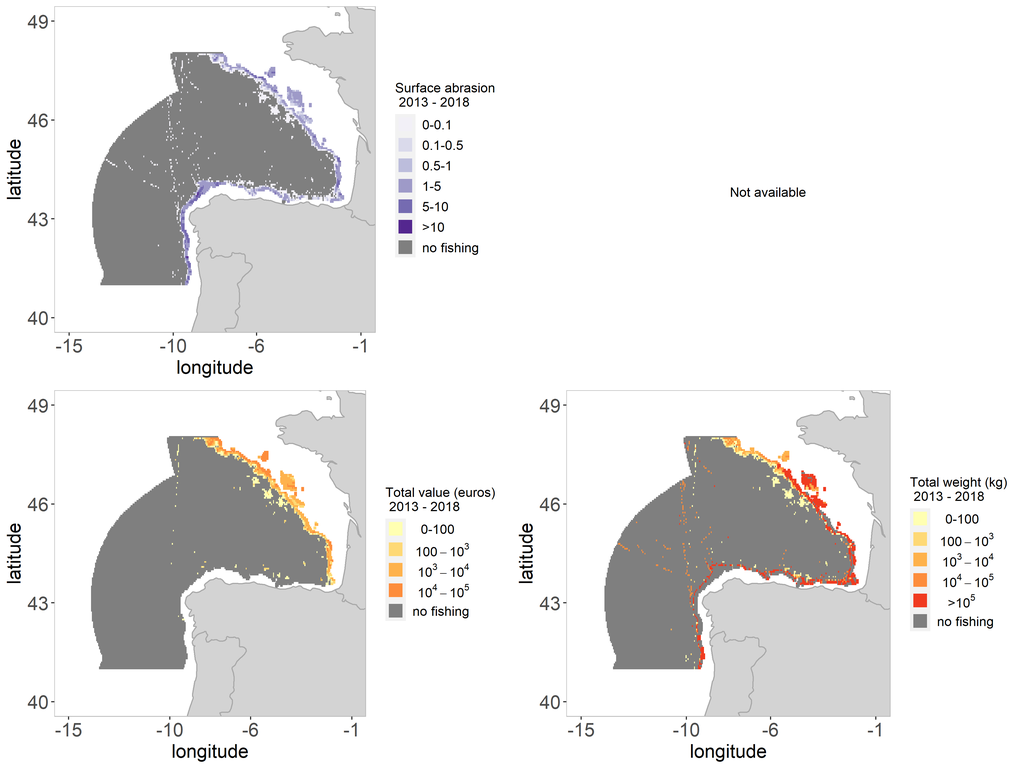

**Figure 1 Geographic distribution of surface abrasion, seabed sensitivity (not shown) and total value and weight from mobile bottom-contacting gear. The maps of surface abrasion, value and weight show the average per year for 2013-2018**

### Pressure

The distribution of fishing intensity in the “Northern area deep” has a strong spatial variation (Figure 2). Areas of higher intensity occur in the Galicia and northern Portugal coast as well as in the border between Spain and France. Areas with lower intensity occur in the central Cantabrian Sea and in the northern part of France.

Fishing pressure is aggregated, both at the regional level as well as at the level of the habitat (Figure 3, right panel). The smallest proportion of habitat with 90% of effort varies between 10-25% for the habitat with fishing (upper bathyal sediment) and between near 0 to 5% for all together but this percentages are highly affected for the large area of very deep seabed included in the analysis. The intensively fished areas represent the ‘core fishing grounds. These grounds seems to be very much aggregated than in other regions but again, these values are highly affected for the inclusion in the analysis of extent areas of unsuitable seabed (Figure 4).

#### Figure 2

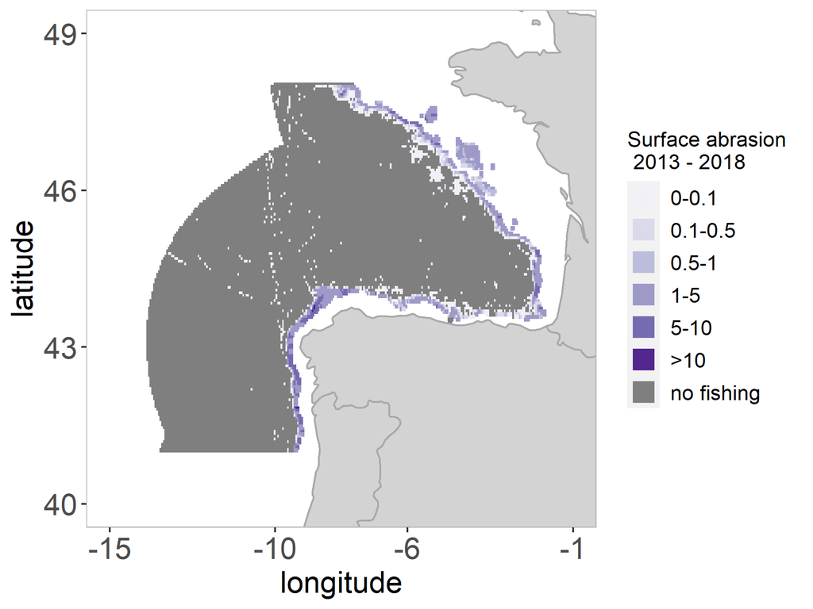

**Figure 2 Surface abrasion, Swept Area Ratio, by mobile bottom-contacting gears (year-1), averaged for the 2013-2018 six-year cycle**

#### Table 2

Table 2 Overview of pressure indicators of all mobile bottom-contacting gears per broad-scale habitat averaged for 2013-2018. I refers to the indicators in Table 1.

| MSFD broad habitat type | Extent of habitat (1000 km<sup>2</sup>) | Number of grid cells | Landings 1000 tonnes | Value 10<sup>6</sup> euro | Swept area 1000 km<sup>2</sup> | Average intensity (I-1) | Prop. of area in fished grid cells (I-2) | Prop. of area fished per year (I-3) | Smallest prop. of area with 90% of fishing effort (I-4) |
| --- | --- | --- | --- | --- | --- | --- | --- | --- | --- |
| Upper bathyal sediment | 22.96 | 1602 | NA | NA | 30.44 | 1.33 | 0.75 | 0.42 | 0.24 |
| Offshore circalittoral sand | 2.73 | 347 | NA | NA | 8.07 | 2.96 | 0.99 | 0.90 | 0.44 |
| Offshore circalittoral mud | 2.09 | 260 | NA | NA | 4.80 | 2.30 | 0.99 | 0.92 | 0.47 |
| Offshore circalittoral coarse sediment | 1.99 | 195 | NA | NA | 4.34 | 2.18 | 1.00 | 0.92 | 0.52 |
| Upper bathyal sediment or Upper bathyal rock and biogenic reef | 5.71 | 520 | NA | NA | 1.05 | 0.18 | 0.22 | 0.08 | 0.07 |
| Upper bathyal rock and biogenic reef | 1.19 | 211 | NA | NA | 0.81 | 0.68 | 0.46 | 0.26 | 0.18 |
| Offshore circalittoral rock and biogenic reef | 0.29 | 48 | NA | NA | 0.59 | 2.04 | 0.90 | 0.88 | 0.42 |
| Offshore circalittoral mixed sediment | 0.08 | 35 | NA | NA | 0.25 | 3.35 | 0.98 | 0.96 | 0.34 |
| Unknown | 0.05 | 20 | NA | NA | 0.22 | 4.72 | 1.00 | 1.00 | 0.15 |
| Lower bathyal sediment | 12.05 | 1264 | NA | NA | 0.14 | 0.01 | 0.21 | 0.01 | 0.09 |
| Abyssal | 329.39 | 15530 | NA | NA | 0.08 | 0.00 | 0.02 | 0.00 | 0.01 |
| Lower bathyal sediment or Lower bathyal rock and biogenic reef | 21.19 | 1456 | NA | NA | 0.07 | 0.00 | 0.05 | 0.00 | 0.02 |
| Circalittoral sand | 0.00 | 3 | NA | NA | 0.00 | 0.74 | 0.20 | 0.20 | 0.33 |
| Lower bathyal rock and biogenic reef | 0.50 | 79 | NA | NA | 0.00 | 0.00 | 0.09 | 0.00 | 0.08 |
| Circalittoral rock and biogenic reef | 0.00 | 2 | NA | NA | 0.00 | 0.00 | 0.02 | 0.00 | NA |

#### Figure 3

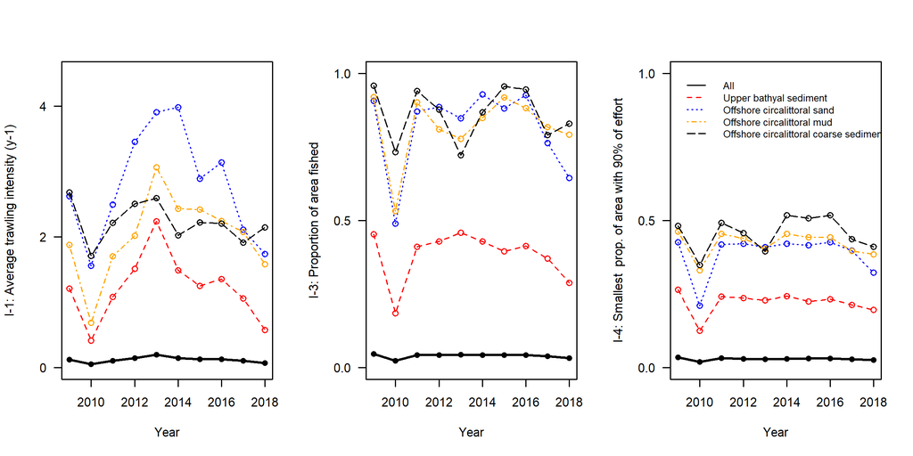

**Figure 3. Time series of (a) mean fishing intensity (surface abrasion), (b) proportion of the surface area of the seafloor fished, (c) aggregation of fishing (proportion of the surface area with 90% of the fishing effort) by habitat. Results represent vessels over 15m (2009-2011) and vessels over 12m (2012-2018).**

#### Figure 4

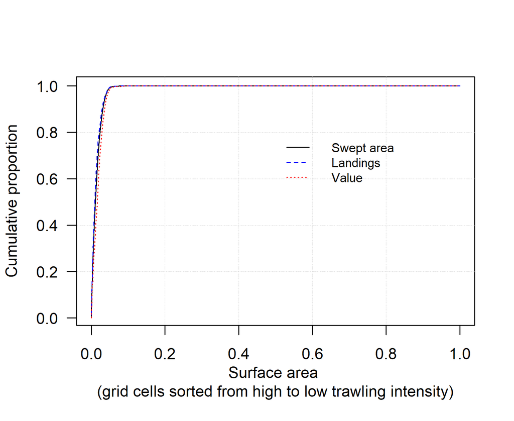

**Figure 4. Cumulative proportion of the swept area, landings and value. Grid cells were sorted from highest to lowest fishing intensity and include non-fished cells. The results are for all mobile bottom-contacting gears based on averaged fishing data per c-square from 2013-2018.**

### Core fishing grounds

No information available

### Fishing by métier

Area swept is estimated for the grid cells that were fished by one MBCG métier, ignoring cells fished by other métiers (Table 3).

#### Table 3

Table 3. Overview of area fished (sum of swept area), landings and value for the different metiers. Area fished in 1000 km2, weight of landings in 1000 tonnes, value of landings in 10^6 euro.

|  | DRB_MOL | OT_CRU | OT_DMF | OT_MI | OT_SPF | SDN_DMF | SSC_DMF | TBB_CRU | TBB_DMF | TBB_MOL |
| --- | --- | --- | --- | --- | --- | --- | --- | --- | --- | --- |
| Area swept (1000 km2) | <0.005 | 5.22 | 44.36 | 0.03 | 0.08 | 1.17 | 0 | 0 | 0.01 | 0 |
| Landings (1000 tonnes) | NA | NA | NA | NA | NA | NA | NA | NA | NA | NA |
| Value (10^6 euro) | NA | NA | NA | NA | NA | NA | NA | NA | NA | NA |
| Landings (1000 tonnes)/Area swept (1000 km2) | NA | NA | NA | NA | NA | NA | NA | NA | NA | NA |
| Value (10^6 euro)/Area swept (1000 km2) | NA | NA | NA | NA | NA | NA | NA | NA | NA | NA |

### Impact

No information available

### Management scenarios

No information available on value/weight of landings.

#### Overview all MSFD habitats

Fishing effort consequences, as a % relative to total swept area, of protecting a certain fraction of each broad habitat type sorted from low to high fished c-squares

| MSFD broad habitat type | Extent of habitat 1000 km<sup>2</sup> | 0.05 | 0.1 | 0.2 | 0.3 | 0.4 | 0.5 | 0.6 | 0.7 | 0.8 | 0.9 |
| --- | --- | --- | --- | --- | --- | --- | --- | --- | --- | --- | --- |
| Upper bathyal sediment | 22.96 | 0.0 | 0.0 | 0.0 | <0.1 | 0.2 | 0.9 | 3.7 | 10.9 | 26.8 | 54.8 |
| Offshore circalittoral sand | 2.73 | 1.4 | 3.6 | 7.0 | 11.3 | 17.7 | 25.1 | 34.9 | 46.7 | 61.3 | 77.7 |
| Offshore circalittoral mud | 2.09 | 2.0 | 5.1 | 11.1 | 16.3 | 23.3 | 31.8 | 40.3 | 50.1 | 62.5 | 80.6 |
| Offshore circalittoral coarse sediment | 1.99 | 2.2 | 4.6 | 9.0 | 15.0 | 22.5 | 31.0 | 40.4 | 50.7 | 64.2 | 80.1 |
| Upper bathyal sediment or Upper bathyal rock and biogenic reef | 5.71 | 0.0 | 0.0 | 0.0 | 0.0 | 0.0 | 0.0 | 0.0 | 0.0 | 0.1 | 3.8 |
| Upper bathyal rock and biogenic reef | 1.19 | 0.0 | 0.0 | 0.0 | 0.0 | 0.0 | 0.0 | 0.1 | 2.3 | 13.9 | 44.8 |
| Offshore circalittoral rock and biogenic reef | 0.29 | 0.0 | 0.2 | 9.4 | 17.8 | 24.1 | 33.2 | 48.8 | 62.7 | 70.1 | 88.1 |
| Offshore circalittoral mixed sediment | 0.08 | 0.9 | 5.2 | 15.8 | 24.7 | 29.8 | 44.6 | 54.4 | 75.4 | 86.0 | 100.0 |
| Unknown | 0.05 | 3.1 | 19.3 | 19.3 | 51.6 | 51.6 | 51.6 | 51.6 | 100.0 | 100.0 | 100.0 |
| Lower bathyal sediment | 12.05 | 0.0 | 0.0 | 0.0 | 0.0 | 0.0 | 0.0 | 0.0 | 0.0 | <0.1 | 5.7 |
| Abyssal | 329.39 | 0.0 | 0.0 | 0.0 | 0.0 | 0.0 | 0.0 | 0.0 | 0.0 | 0.0 | 0.0 |
| Lower bathyal sediment or Lower bathyal rock and biogenic reef | 21.19 | 0.0 | 0.0 | 0.0 | 0.0 | 0.0 | 0.0 | 0.0 | 0.0 | 0.0 | 0.0 |
| Circalittoral sand | 0 | 0.0 | 0.0 | 0.0 | 0.0 | 0.0 | 0.0 | 0.0 | 0.0 | 0.0 | 100.0 |
| Lower bathyal rock and biogenic reef | 0.5 | 0.0 | 0.0 | 0.0 | 0.0 | 0.0 | 0.0 | 0.0 | 0.0 | 0.0 | 0.0 |
| Circalittoral rock and biogenic reef | 0 | 0.0 | 0.0 | 0.0 | 0.0 | 0.0 | 0.0 | 0.0 | 0.0 | 0.0 | 0.0 |

## Northern Iberian Coast

### Summary

The physical disturbance pressures from mobile bottom-contacting fishing gears varies spatially in the “Northern Iberian coast” subdivision with 78% of the grid cells (I-2), and 54% of the surface area (I-3), in the depth zone 0-200m, being fished on average per year for the period 2013-2018 (Table 1). Fishing is relatively aggregated with 90% of the pressure occurring in 40% of grid cells (I-4).

The ICES methods for computing impact are not available in the region and therefore this part of the analysis has not been completed.

Maps of spatial distribution of intensity, seafloor sensitivity and economic value and weight of fisheries landings are shown in Figure 1. It is evident from the weight map that there is a mistake in the weights for the region, and weights are not presented in further analyses.

#### Table 1

Table 1. Pressure and impact indicators for 2013-2018

| Indicators | 0 to 200 m | 200 to 800 m | more than 800 m |
| --- | --- | --- | --- |
| Average intensity (I-1) | 1.39 | NA | NA |
| Proportion of area in fished cells (I-2) | 0.78 | NA | NA |
| Proportion of area fished per year (I-3) | 0.54 | NA | NA |
| Smallest prop. of area in fished cells with 90% of fishing effort (I-4) | 0.40 | NA | NA |
| Proportion of area in unfished cells (I-5) | 0.22 | NA | NA |
| Average PD impact (I-6) | NA | NA | NA |
| Average L1 impact (I-6) | NA | NA | NA |
| Proportion of area with PD impact < 0.2 (I-7) | NA | NA | NA |
| Proportion of area with L1 impact < 0.2 (I-7) | NA | NA | NA |

#### Figure 1

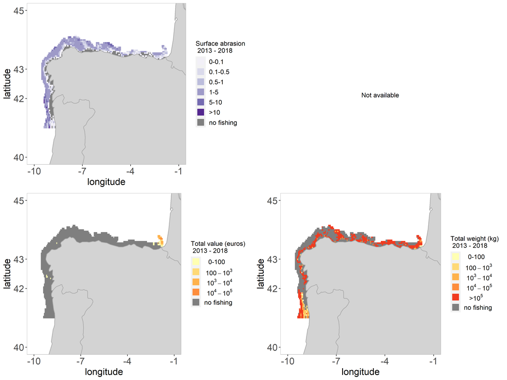

**Figure 1 Geographic distribution of surface abrasion, seabed sensitivity (not shown) and total value and weight from mobile bottom-contacting gear. The maps of surface abrasion, value and weight show the average per year for 2013-2018**

### Pressure

The distribution of fishing intensity in the “Northern Iberian coast” has a strong spatial variation (Figure 2). Areas of higher intensity occur in areas of northern Portugal and in the shelf break of Galicia and Asturias. Areas with lower intensity occur in the central Cantabrian Sea and in the shallowest areas (<100 m) since trawling in these areas is forbidden in this part of Spain.

There is a large peak in intensity in most of the habitats, which may be due to erroneous data. Both average trawling intensity and proportion of area fished show a similar trend with a negative peak in 2010 and minor changes in the rest of years (Figure 3, compare left and middle panel). This shows that changes in intensity have not affected the spatial distribution of the footprint much. The pattern in Figure 3 suggests that there may be errors in the effort data.

#### Figure 2

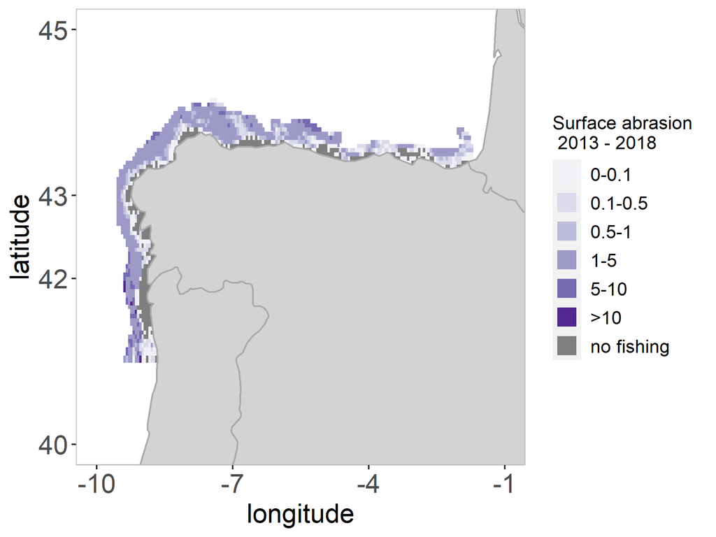

**Figure 2 Surface abrasion, Swept Area Ratio, by mobile bottom-contacting gears (year-1), averaged for the 2013-2018 six-year cycle**

#### Table 2

Table 2 Overview of pressure indicators of all mobile bottom-contacting gears per broad-scale habitat averaged for 2013-2018. I refers to the indicators in Table 1.

| MSFD broad habitat type | Extent of habitat (1000 km<sup>2</sup>) | Number of grid cells | Landings 1000 tonnes | Value 10<sup>6</sup> euro | Swept area 1000 km<sup>2</sup> | Average intensity (I-1) | Prop. of area in fished grid cells (I-2) | Prop. of area fished per year (I-3) | Smallest prop. of area with 90% of fishing effort (I-4) |
| --- | --- | --- | --- | --- | --- | --- | --- | --- | --- |
| Offshore circalittoral sand | 7.46 | 790 | NA | NA | 16.00 | 2.14 | 0.97 | 0.80 | 0.41 |
| Offshore circalittoral mud | 5.18 | 508 | NA | NA | 12.17 | 2.35 | 0.99 | 0.87 | 0.45 |
| Offshore circalittoral rock and biogenic reef | 3.33 | 590 | NA | NA | 4.84 | 1.45 | 0.87 | 0.59 | 0.33 |
| Upper bathyal sediment | 1.46 | 189 | NA | NA | 3.73 | 2.56 | 0.99 | 0.79 | 0.46 |
| Offshore circalittoral mixed sediment | 0.73 | 173 | NA | NA | 1.85 | 2.55 | 0.96 | 0.86 | 0.34 |
| Offshore circalittoral coarse sediment | 1.23 | 298 | NA | NA | 1.23 | 0.99 | 0.93 | 0.64 | 0.35 |
| Circalittoral rock and biogenic reef | 2.59 | 513 | NA | NA | 0.60 | 0.23 | 0.59 | 0.15 | 0.20 |
| Circalittoral sand | 2.03 | 510 | NA | NA | 0.55 | 0.27 | 0.61 | 0.16 | 0.14 |
| Circalittoral mud | 0.93 | 214 | NA | NA | 0.45 | 0.48 | 0.63 | 0.17 | 0.08 |
| Upper bathyal rock and biogenic reef | 0.09 | 36 | NA | NA | 0.34 | 3.57 | 0.89 | 0.83 | 0.33 |
| Circalittoral mixed sediment | 0.43 | 105 | NA | NA | 0.15 | 0.35 | 0.73 | 0.12 | 0.16 |
| Circalittoral coarse sediment | 0.45 | 216 | NA | NA | 0.15 | 0.34 | 0.84 | 0.26 | 0.21 |
| Infralittoral rock and biogenic reef | 0.78 | 348 | NA | NA | 0.04 | 0.06 | 0.41 | 0.05 | 0.14 |
| Unknown | 0.03 | 273 | NA | NA | 0.03 | 1.14 | 0.73 | 0.57 | 0.01 |
| Infralittoral sand | 0.44 | 290 | NA | NA | 0.02 | 0.04 | 0.38 | 0.04 | 0.12 |
| Infralittoral mixed sediment | 0.12 | 46 | NA | NA | 0.01 | 0.06 | 0.27 | 0.06 | 0.17 |
| Infralittoral coarse sediment | 0.04 | 63 | NA | NA | 0.01 | 0.15 | 0.50 | 0.11 | 0.17 |
| Lower bathyal sediment | 0.00 | 1 | NA | NA | 0.00 | 1.15 | 1.00 | 1.00 | 1.00 |
| Infralittoral mud | 0.14 | 105 | NA | NA | 0.00 | 0.02 | 0.32 | 0.02 | 0.12 |
| Upper bathyal sediment or Upper bathyal rock and biogenic reef | 0.00 | 2 | NA | NA | 0.00 | 1.16 | 1.00 | 1.00 | NA |

#### Figure 3

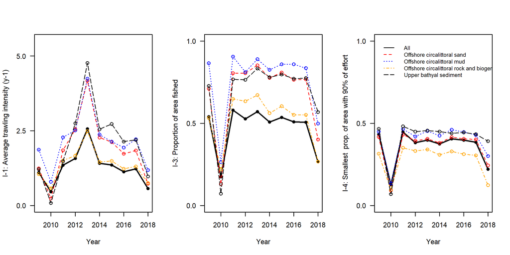

**Figure 3. Time series of (a) mean fishing intensity (surface abrasion), (b) proportion of the surface area of the seafloor fished, (c) aggregation of fishing (proportion of the surface area with 90% of the fishing effort) by habitat. Results represent vessels over 15m (2009-2011) and vessels over 12m (2012-2018).**

#### Figure 4

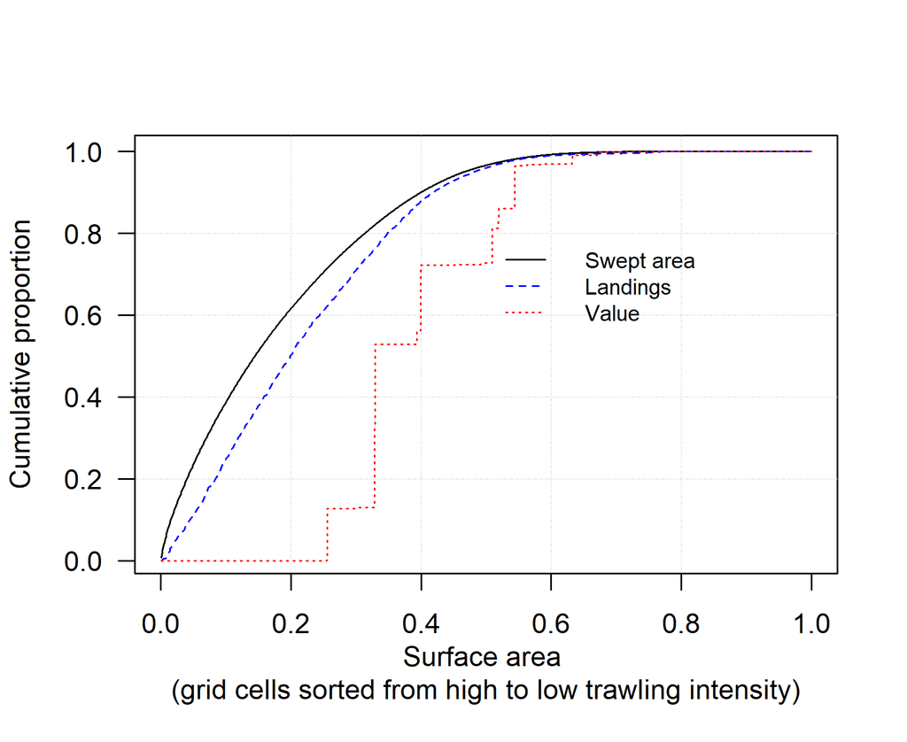

**Figure 4. Cumulative proportion of the swept area, landings and value. Grid cells were sorted from highest to lowest fishing intensity and include non-fished cells. The results are for all mobile bottom-contacting gears based on averaged fishing data per c-square from 2013-2018.**

### Core fishing grounds

No information available

### Fishing by métier

Area swept is estimated for the grid cells that were fished by one MBCG métier, ignoring cells fished by other métiers (Table 3).

#### Table 3

Table 3. Overview of area fished (sum of swept area), landings and value for the different metiers. Area fished in 1000 km2, weight of landings in 1000 tonnes, value of landings in 10^6 euro.

|  | DRB_MOL | OT_CRU | OT_DMF | OT_MI | OT_SPF | SDN_DMF | SSC_DMF | TBB_CRU | TBB_DMF | TBB_MOL |
| --- | --- | --- | --- | --- | --- | --- | --- | --- | --- | --- |
| Area swept (1000 km2) | 0.02 | 10.38 | 31.79 | <0.005 | 0.02 | 0 | 0 | 0 | 0 | 0 |
| Landings (1000 tonnes) | NA | NA | NA | NA | NA | NA | NA | NA | NA | NA |
| Value (10^6 euro) | NA | NA | NA | NA | NA | NA | NA | NA | NA | NA |
| Landings (1000 tonnes)/Area swept (1000 km2) | NA | NA | NA | NA | NA | NA | NA | NA | NA | NA |
| Value (10^6 euro)/Area swept (1000 km2) | NA | NA | NA | NA | NA | NA | NA | NA | NA | NA |

### Impact

No information available

### Management scenarios

No information available on value/weight of landings.

#### Overview all MSFD habitats

Fishing effort consequences, as a % relative to total swept area, of protecting a certain fraction of each broad habitat type sorted from low to high fished c-squares

| MSFD broad habitat type | Extent of habitat 1000 km<sup>2</sup> | 0.05 | 0.1 | 0.2 | 0.3 | 0.4 | 0.5 | 0.6 | 0.7 | 0.8 | 0.9 |
| --- | --- | --- | --- | --- | --- | --- | --- | --- | --- | --- | --- |
| Offshore circalittoral sand | 7.46 | <0.1 | 0.3 | 2.6 | 7.2 | 14.0 | 22.1 | 33.0 | 44.6 | 58.6 | 76.6 |
| Offshore circalittoral mud | 5.18 | 0.1 | 0.8 | 5.3 | 12.9 | 21.1 | 30.0 | 38.6 | 49.2 | 61.1 | 75.7 |
| Offshore circalittoral rock and biogenic reef | 3.33 | 0.0 | 0.0 | 0.2 | 2.9 | 6.6 | 11.6 | 18.5 | 29.4 | 42.6 | 62.4 |
| Upper bathyal sediment | 1.46 | 0.2 | 0.5 | 2.3 | 7.0 | 15.9 | 24.8 | 36.2 | 51.5 | 64.9 | 81.2 |
| Offshore circalittoral mixed sediment | 0.73 | <0.1 | 0.7 | 4.5 | 11.6 | 22.2 | 33.0 | 43.9 | 55.4 | 69.4 | 83.8 |
| Offshore circalittoral coarse sediment | 1.23 | 0.0 | <0.1 | 1.8 | 6.3 | 14.2 | 21.8 | 33.9 | 43.7 | 58.7 | 74.5 |
| Circalittoral rock and biogenic reef | 2.59 | 0.0 | 0.0 | 0.0 | 0.0 | 0.0 | 0.4 | 1.7 | 6.4 | 13.4 | 34.9 |
| Circalittoral sand | 2.03 | 0.0 | 0.0 | 0.0 | 0.0 | <0.1 | 0.5 | 2.3 | 6.4 | 12.1 | 30.7 |
| Circalittoral mud | 0.93 | 0.0 | 0.0 | 0.0 | 0.0 | <0.1 | 0.7 | 2.6 | 5.3 | 10.2 | 22.9 |
| Upper bathyal rock and biogenic reef | 0.09 | 0.0 | 0.0 | 2.5 | 11.6 | 23.0 | 29.4 | 42.3 | 57.3 | 70.3 | 84.2 |
| Circalittoral mixed sediment | 0.43 | 0.0 | 0.0 | 0.0 | 0.4 | 1.9 | 2.9 | 6.6 | 10.2 | 12.8 | 21.9 |
| Circalittoral coarse sediment | 0.45 | 0.0 | 0.0 | <0.1 | 0.5 | 2.0 | 4.6 | 11.2 | 19.5 | 33.6 | 60.4 |
| Infralittoral rock and biogenic reef | 0.78 | 0.0 | 0.0 | 0.0 | 0.0 | 0.0 | 0.0 | <0.1 | 1.8 | 10.3 | 35.3 |
| Unknown | 0.03 | 0.0 | 0.0 | 0.0 | <0.1 | 0.2 | 16.0 | 100.0 | 100.0 | 100.0 | 100.0 |
| Infralittoral sand | 0.44 | 0.0 | 0.0 | 0.0 | 0.0 | 0.0 | 0.0 | 0.0 | 1.8 | 12.3 | 44.3 |
| Infralittoral mixed sediment | 0.12 | 0.0 | 0.0 | 0.0 | 0.0 | 0.0 | 0.0 | 0.0 | 0.0 | 12.8 | 37.0 |
| Infralittoral coarse sediment | 0.04 | 0.0 | 0.0 | 0.0 | 0.0 | 0.0 | 0.0 | 5.0 | 11.0 | 21.9 | 40.7 |
| Lower bathyal sediment | 0 | 100.0 | 100.0 | 100.0 | 100.0 | 100.0 | 100.0 | 100.0 | 100.0 | 100.0 | 100.0 |
| Infralittoral mud | 0.14 | 0.0 | 0.0 | 0.0 | 0.0 | 0.0 | 0.0 | 0.0 | <0.1 | 2.5 | 34.6 |
| Upper bathyal sediment or Upper bathyal rock and biogenic reef | 0 | 9.9 | 100.0 | 100.0 | 100.0 | 100.0 | 100.0 | 100.0 | 100.0 | 100.0 | 100.0 |

## Western Iberian Coast

### Summary

The physical disturbance pressures from mobile bottom-contacting fishing gears varies spatially in the Western Iberian coast subdivision with 70 % of the grid cells (I-2), and 52% of the surface area (I-3) being fished on average per year for the period 2013-2018 (Table 1) at depths <200. Fishing is very aggregated with 90% of the pressure occurring in 36% of grid cells (I-4).

The ICES methods for computing impact are not available at the moment in the region and therefore this part of the analysis has not been completed.

Maps of spatial distribution of intensity, and weight of fisheries landings are shown in Figure 1. It is evident from the weight map that there is a mistake in the weights for the region, and weights are not presented in further analyses.

#### Table 1

Table 1. Pressure and impact indicators for 2013-2018

| Indicators | 0 to 200 m | 200 to 800 m | more than 800 m |
| --- | --- | --- | --- |
| Average intensity (I-1) | 2.68 | NA | NA |
| Proportion of area in fished cells (I-2) | 0.70 | NA | NA |
| Proportion of area fished per year (I-3) | 0.52 | NA | NA |
| Smallest prop. of area in fished cells with 90% of fishing effort (I-4) | 0.36 | NA | NA |
| Proportion of area in unfished cells (I-5) | 0.30 | NA | NA |
| Average PD impact (I-6) | NA | NA | NA |
| Average L1 impact (I-6) | NA | NA | NA |
| Proportion of area with PD impact < 0.2 (I-7) | NA | NA | NA |
| Proportion of area with L1 impact < 0.2 (I-7) | NA | NA | NA |

#### Figure 1

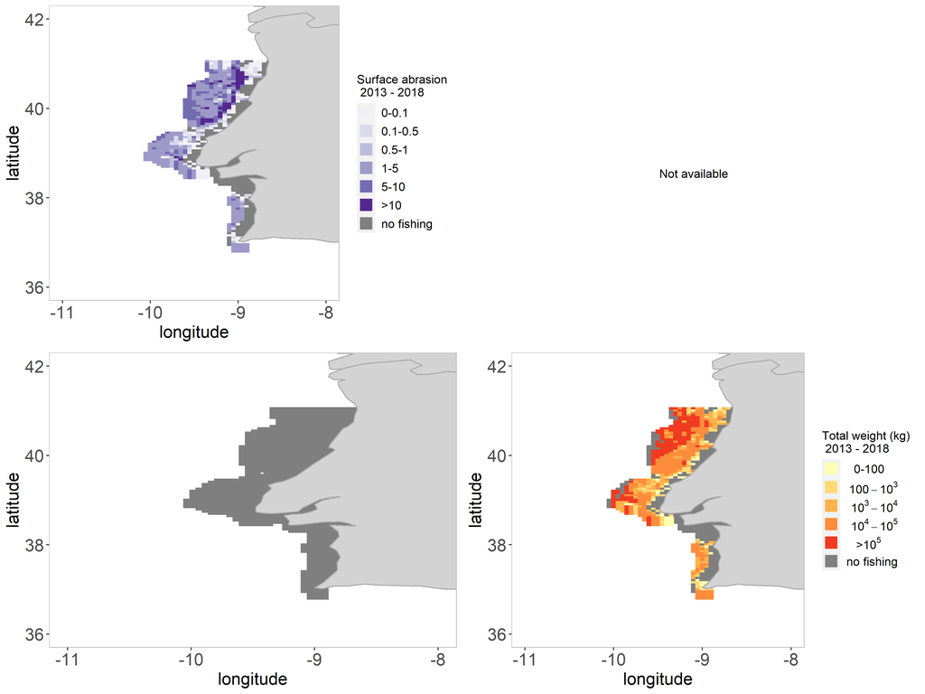

**Figure 1 Geographic distribution of surface abrasion, seabed sensitivity (not shown) and total value and weight from mobile bottom-contacting gear. The maps of surface abrasion, value and weight show the average per year for 2013-2018**

### Pressure

The proportion of area subject to fishing pressure differs between broad-scale habitats and is highest in Offshore circalittoral mixed sediment (95% of grid cells fished) and Upper bathyal sediment (93% of grid cells fished) (Table 2). Fishing intensity is highest in Circalittoral mixed sediment (average intensity = 7.07 year-1) and Offshore circalittoral mixed sediment (average intensity = 4.23 year-1).

Total fishing intensity is largely unchanged over time (Figure 3). There is a large decreasing peak in intensity in circalittoral mixed sediment and circalittoral sand in the period 2011-2012, while the circalittoral mud and offshore circalittoral sand showed the inverse pattern, with an increase on the fishing intensity on this period. The proportion of area fished also showed temporal variations (Figure 3). This shows that the spatial distribution of the footprint down to deeper areas, showing an increase of the proportion of area fished since 2012 in offshore circalittoral sand and mud while area fished decrease in circalittoral mixed sediment and circalittoral sand.

#### Figure 2

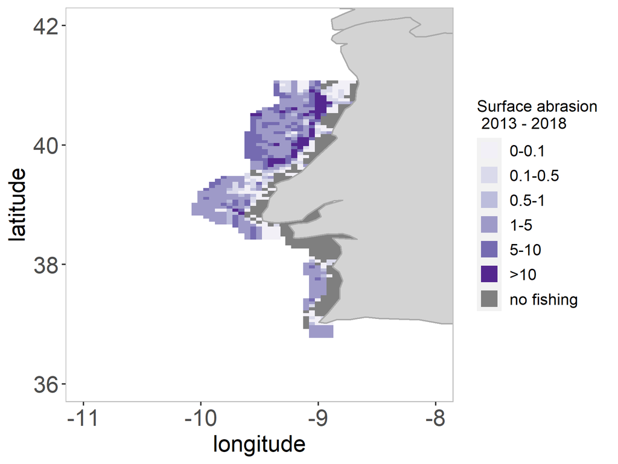

**Figure 2 Surface abrasion, Swept Area Ratio, by mobile bottom-contacting gears (year-1), averaged for the 2013-2018 six-year cycle**

#### Table 2

Table 2 Overview of pressure indicators of all mobile bottom-contacting gears per broad-scale habitat averaged for 2013-2018. I refers to the indicators in Table 1.

| MSFD broad habitat type | Extent of habitat (1000 km<sup>2</sup>) | Number of grid cells | Landings 1000 tonnes | Value 10<sup>6</sup> euro | Swept area 1000 km<sup>2</sup> | Average intensity (I-1) | Prop. of area in fished grid cells (I-2) | Prop. of area fished per year (I-3) | Smallest prop. of area with 90% of fishing effort (I-4) |
| --- | --- | --- | --- | --- | --- | --- | --- | --- | --- |
| Offshore circalittoral mud | 5.51 | 435 | NA | NA | 18.29 | 3.32 | 0.88 | 0.77 | 0.43 |
| Circalittoral mixed sediment | 1.95 | 259 | NA | NA | 13.81 | 7.07 | 0.82 | 0.59 | 0.15 |
| Offshore circalittoral sand | 1.68 | 293 | NA | NA | 5.25 | 3.13 | 0.88 | 0.79 | 0.36 |
| Circalittoral sand | 2.45 | 339 | NA | NA | 4.76 | 1.94 | 0.65 | 0.30 | 0.12 |
| Offshore circalittoral rock and biogenic reef | 1.37 | 274 | NA | NA | 3.28 | 2.40 | 0.92 | 0.70 | 0.34 |
| Offshore circalittoral mixed sediment | 0.49 | 166 | NA | NA | 2.06 | 4.23 | 0.95 | 0.87 | 0.27 |
| Upper bathyal sediment | 0.31 | 71 | NA | NA | 1.19 | 3.81 | 0.93 | 0.86 | 0.37 |
| Circalittoral rock and biogenic reef | 1.33 | 227 | NA | NA | 0.92 | 0.70 | 0.67 | 0.27 | 0.17 |
| Circalittoral mud | 0.49 | 157 | NA | NA | 0.17 | 0.34 | 0.41 | 0.09 | 0.13 |
| Offshore circalittoral coarse sediment | 0.05 | 11 | NA | NA | 0.13 | 2.71 | 0.95 | 0.88 | 0.36 |
| Upper bathyal rock and biogenic reef | 0.03 | 21 | NA | NA | 0.06 | 1.81 | 0.95 | 0.86 | 0.19 |
| Upper bathyal sediment or Upper bathyal rock and biogenic reef | 0.01 | 12 | NA | NA | 0.04 | 2.98 | 1.00 | 0.96 | 0.50 |
| Infralittoral sand | 0.53 | 158 | NA | NA | 0.04 | 0.07 | 0.21 | 0.04 | 0.04 |
| Unknown | 0.11 | 102 | NA | NA | 0.04 | 0.31 | 0.06 | 0.05 | 0.01 |
| Infralittoral rock and biogenic reef | 0.10 | 75 | NA | NA | 0.01 | 0.15 | 0.17 | 0.07 | 0.04 |
| Lower bathyal sediment or Lower bathyal rock and biogenic reef | 0.00 | 1 | NA | NA | 0.00 | 4.56 | 1.00 | 1.00 | 1.00 |
| Infralittoral mud | 0.02 | 34 | NA | NA | 0.00 | 0.04 | 0.07 | 0.02 | 0.12 |
| Infralittoral mixed sediment | 0.02 | 28 | NA | NA | 0.00 | 0.04 | 0.10 | 0.04 | 0.11 |
| Circalittoral coarse sediment | 0.00 | 1 | NA | NA | 0.00 | 0.00 | 0.00 | 0.00 | NA |

#### Figure 3

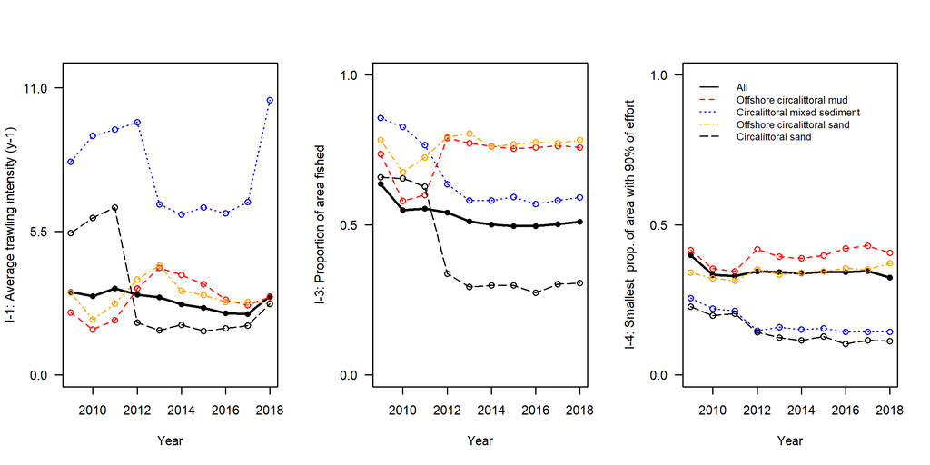

**Figure 3. Time series of (a) mean fishing intensity (surface abrasion), (b) proportion of the surface area of the seafloor fished, (c) aggregation of fishing (proportion of the surface area with 90% of the fishing effort) by habitat. Results represent vessels over 15m (2009-2011) and vessels over 12m (2012-2018).**

#### Figure 4

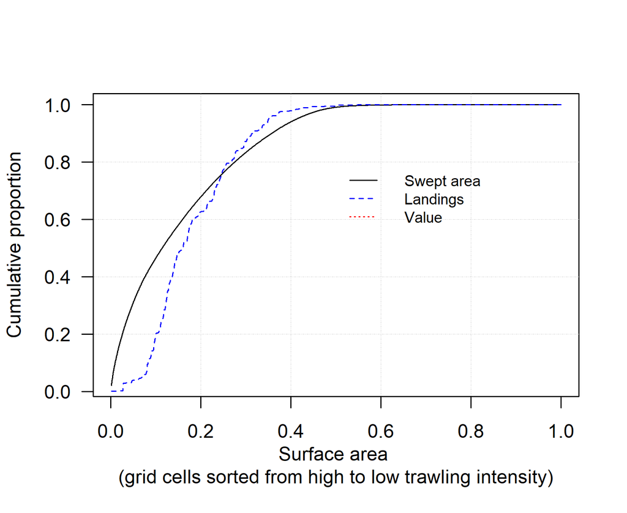

**Figure 4. Cumulative proportion of the swept area, landings and value. Grid cells were sorted from highest to lowest fishing intensity and include non-fished cells. The results are for all mobile bottom-contacting gears based on averaged fishing data per c-square from 2013-2018.**

### Core fishing grounds

No information available

### Fishing by métier

Area swept is estimated for the grid cells that were fished by one MBCG métier, ignoring cells fished by other métiers (Table 3).

#### Table 3

Table 3. Overview of area fished (sum of swept area), landings and value for the different metiers. Area fished in 1000 km2, weight of landings in 1000 tonnes, value of landings in 10^6 euro.

|  | DRB_MOL | OT_CRU | OT_DMF | OT_MI | OT_SPF | SDN_DMF | SSC_DMF | TBB_CRU | TBB_DMF | TBB_MOL |
| --- | --- | --- | --- | --- | --- | --- | --- | --- | --- | --- |
| Area swept (1000 km2) | 0.03 | 44.93 | 5.25 | 0 | 0 | 0 | 0 | 0 | 0 | 0 |
| Landings (1000 tonnes) | NA | NA | NA | NA | NA | NA | NA | NA | NA | NA |
| Value (10^6 euro) | NA | NA | NA | NA | NA | NA | NA | NA | NA | NA |
| Landings (1000 tonnes)/Area swept (1000 km2) | NA | NA | NA | NA | NA | NA | NA | NA | NA | NA |
| Value (10^6 euro)/Area swept (1000 km2) | NA | NA | NA | NA | NA | NA | NA | NA | NA | NA |

### Impact

No information available

### Management scenarios

No information available on value/weight of landings.

#### Overview all MSFD habitats

Fishing effort consequences, as a % relative to total swept area, of protecting a certain fraction of each broad habitat type sorted from low to high fished c-squares

| MSFD broad habitat type | Extent of habitat 1000 km<sup>2</sup> | 0.05 | 0.1 | 0.2 | 0.3 | 0.4 | 0.5 | 0.6 | 0.7 | 0.8 | 0.9 |
| --- | --- | --- | --- | --- | --- | --- | --- | --- | --- | --- | --- |
| Offshore circalittoral mud | 5.51 | 0.0 | 0.0 | 0.2 | 3.7 | 11.9 | 21.5 | 31.8 | 43.8 | 59.1 | 76.1 |
| Circalittoral mixed sediment | 1.95 | 0.0 | 0.0 | <0.1 | 0.1 | 0.5 | 3.2 | 11.8 | 23.6 | 41.3 | 64.8 |
| Offshore circalittoral sand | 1.68 | 0.0 | 0.0 | 0.9 | 5.2 | 14.6 | 25.5 | 37.0 | 51.0 | 65.8 | 81.1 |
| Circalittoral sand | 2.45 | 0.0 | 0.0 | 0.0 | 0.0 | <0.1 | 0.2 | 0.6 | 2.1 | 10.7 | 41.8 |
| Offshore circalittoral rock and biogenic reef | 1.37 | 0.0 | <0.1 | 0.5 | 1.9 | 8.6 | 15.5 | 26.4 | 40.4 | 54.6 | 71.6 |
| Offshore circalittoral mixed sediment | 0.49 | 0.0 | <0.1 | 2.6 | 8.6 | 13.2 | 22.7 | 35.7 | 46.6 | 58.6 | 82.6 |
| Upper bathyal sediment | 0.31 | 0.0 | <0.1 | 5.3 | 10.5 | 18.3 | 26.1 | 40.7 | 57.7 | 62.9 | 83.3 |
| Circalittoral rock and biogenic reef | 1.33 | 0.0 | 0.0 | 0.0 | 0.0 | 0.4 | 1.3 | 3.1 | 5.3 | 17.7 | 37.9 |
| Circalittoral mud | 0.49 | 0.0 | 0.0 | 0.0 | 0.0 | 0.0 | 0.0 | 0.2 | 3.6 | 6.2 | 13.2 |
| Offshore circalittoral coarse sediment | 0.05 | 1.8 | 9.9 | 20.4 | 20.4 | 20.4 | 31.4 | 48.7 | 100.0 | 100.0 | 100.0 |
| Upper bathyal rock and biogenic reef | 0.03 | 0.0 | 1.5 | 6.9 | 26.5 | 46.3 | 46.3 | 70.3 | 70.3 | 100.0 | 100.0 |
| Upper bathyal sediment or Upper bathyal rock and biogenic reef | 0.01 | 4.6 | 10.2 | 18.5 | 26.8 | 26.8 | 39.4 | 56.8 | 56.8 | 100.0 | 100.0 |
| Infralittoral sand | 0.53 | 0.0 | 0.0 | 0.0 | 0.0 | 0.0 | 0.0 | 0.0 | 0.0 | 0.4 | 4.9 |
| Unknown | 0.11 | 0.0 | 0.0 | 0.0 | 0.0 | 0.0 | 0.0 | 0.0 | 0.0 | 0.0 | 0.0 |
| Infralittoral rock and biogenic reef | 0.1 | 0.0 | 0.0 | 0.0 | 0.0 | 0.0 | 0.0 | 0.0 | 0.0 | 0.0 | 7.5 |
| Lower bathyal sediment or Lower bathyal rock and biogenic reef | 0 | 100.0 | 100.0 | 100.0 | 100.0 | 100.0 | 100.0 | 100.0 | 100.0 | 100.0 | 100.0 |
| Infralittoral mud | 0.02 | 0.0 | 0.0 | 0.0 | 0.0 | 0.0 | 0.0 | 0.0 | 0.0 | 0.0 | 0.0 |
| Infralittoral mixed sediment | 0.02 | 0.0 | 0.0 | 0.0 | 0.0 | 0.0 | 0.0 | 0.0 | 0.0 | 0.0 | 0.7 |
| Circalittoral coarse sediment | 0 | NaN | NaN | NaN | NaN | NaN | NaN | NaN | NaN | NaN | NaN |

## Gulf of Cadiz

### Summary

The physical disturbance pressures from mobile bottom-contacting fishing gears varies spatially in the Gulf of Cadiz subdivision with 49% of the grid cells (I-2), and 16% of the surface area (I-3) being fished on average per year for the period 2013-2018 (Table 1). Fishing is very aggregated with 90% of the pressure occurring in 10% of grid cells (I-4).

The ICES methods for computing impact are not available at the moment in the region and therefore this part of the analysis has not been completed.

Maps of spatial distribution of intensity, economic value and weight of fisheries landings are shown in Figure 1, although the map of economic value seems incomplete in the region. It is evident from the weight map that there is a mistake in the values for the region, and weights are not presented in further analyses.

#### Table 1

Table 1. Pressure and impact indicators for 2013-2018

| Indicators | 0 to 200 m | 200 to 800 m | more than 800 m |
| --- | --- | --- | --- |
| Average intensity (I-1) | 0.70 | NA | NA |
| Proportion of area in fished cells (I-2) | 0.49 | NA | NA |
| Proportion of area fished per year (I-3) | 0.16 | NA | NA |
| Smallest prop. of area in fished cells with 90% of fishing effort (I-4) | 0.10 | NA | NA |
| Proportion of area in unfished cells (I-5) | 0.51 | NA | NA |
| Average PD impact (I-6) | NA | NA | NA |
| Average L1 impact (I-6) | NA | NA | NA |
| Proportion of area with PD impact < 0.2 (I-7) | NA | NA | NA |
| Proportion of area with L1 impact < 0.2 (I-7) | NA | NA | NA |

#### Figure 1

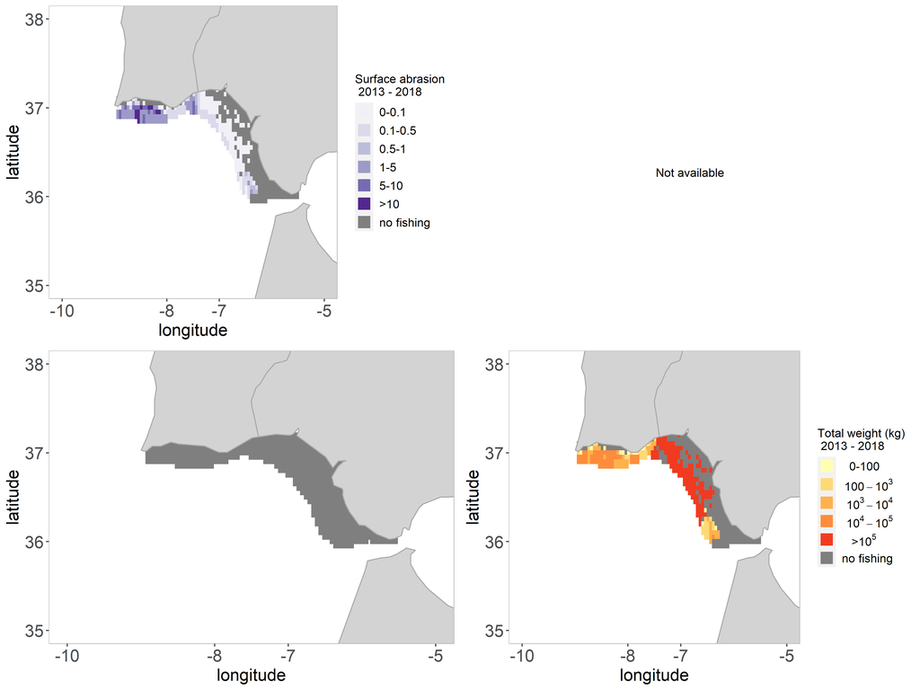

**Figure 1 Geographic distribution of surface abrasion, seabed sensitivity (not shown) and total value and weight from mobile bottom-contacting gear. The maps of surface abrasion, value and weight show the average per year for 2013-2018**

### Pressure

#### Figure 2

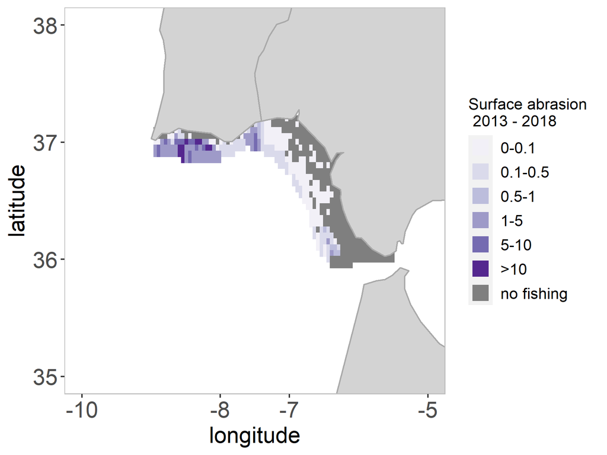

**Figure 2 Surface abrasion, Swept Area Ratio, by mobile bottom-contacting gears (year-1), averaged for the 2013-2018 six-year cycle**

#### Table 2

Table 2 Overview of pressure indicators of all mobile bottom-contacting gears per broad-scale habitat averaged for 2013-2018. I refers to the indicators in Table 1.

| MSFD broad habitat type | Extent of habitat (1000 km<sup>2</sup>) | Number of grid cells | Landings 1000 tonnes | Value 10<sup>6</sup> euro | Swept area 1000 km<sup>2</sup> | Average intensity (I-1) | Prop. of area in fished grid cells (I-2) | Prop. of area fished per year (I-3) | Smallest prop. of area with 90% of fishing effort (I-4) |
| --- | --- | --- | --- | --- | --- | --- | --- | --- | --- |
| Offshore circalittoral mud | 2.17 | 136 | NA | NA | 4.24 | 1.96 | 0.95 | 0.43 | 0.24 |
| Circalittoral mud | 2.31 | 202 | NA | NA | 1.78 | 0.77 | 0.57 | 0.12 | 0.07 |
| Circalittoral mixed sediment | 0.37 | 72 | NA | NA | 0.58 | 1.56 | 0.73 | 0.28 | 0.17 |
| Circalittoral sand | 2.00 | 205 | NA | NA | 0.33 | 0.17 | 0.35 | 0.07 | 0.07 |
| Circalittoral rock and biogenic reef | 0.17 | 111 | NA | NA | 0.17 | 0.99 | 0.22 | 0.14 | 0.07 |
| Offshore circalittoral mixed sediment | 0.07 | 29 | NA | NA | 0.16 | 2.22 | 1.00 | 0.50 | 0.34 |
| Offshore circalittoral sand | 0.65 | 48 | NA | NA | 0.14 | 0.21 | 0.58 | 0.17 | 0.25 |
| Offshore circalittoral rock and biogenic reef | 0.03 | 41 | NA | NA | 0.13 | 4.73 | 0.89 | 0.79 | 0.32 |
| Infralittoral sand | 0.89 | 172 | NA | NA | 0.05 | 0.06 | 0.24 | 0.05 | 0.05 |
| Upper bathyal sediment | 0.04 | 23 | NA | NA | 0.05 | 1.05 | 0.73 | 0.22 | 0.22 |
| Infralittoral mud | 0.19 | 71 | NA | NA | 0.02 | 0.10 | 0.38 | 0.10 | 0.07 |
| Infralittoral mixed sediment | 0.17 | 37 | NA | NA | 0.01 | 0.03 | 0.31 | 0.03 | 0.11 |
| Infralittoral rock and biogenic reef | 0.34 | 96 | NA | NA | 0.00 | 0.01 | 0.04 | 0.01 | 0.03 |
| Offshore circalittoral coarse sediment | 0.07 | 12 | NA | NA | 0.00 | 0.03 | 0.40 | 0.03 | 0.17 |
| Unknown | 0.01 | 27 | NA | NA | 0.00 | 0.16 | 0.73 | 0.16 | 0.07 |
| Infralittoral coarse sediment | 0.11 | 30 | NA | NA | 0.00 | 0.01 | 0.08 | 0.01 | 0.03 |
| Circalittoral coarse sediment | 0.10 | 32 | NA | NA | 0.00 | 0.00 | 0.10 | 0.00 | 0.03 |
| Upper bathyal rock and biogenic reef | 0.00 | 1 | NA | NA | 0.00 | 0.00 | 0.00 | 0.00 | NA |

#### Figure 3

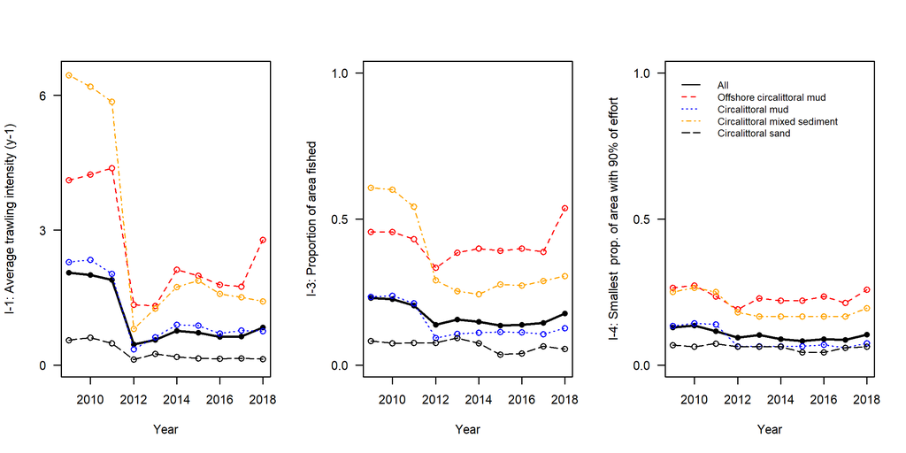

**Figure 3. Time series of (a) mean fishing intensity (surface abrasion), (b) proportion of the surface area of the seafloor fished, (c) aggregation of fishing (proportion of the surface area with 90% of the fishing effort) by habitat. Results represent vessels over 15m (2009-2011) and vessels over 12m (2012-2018).**

#### Figure 4

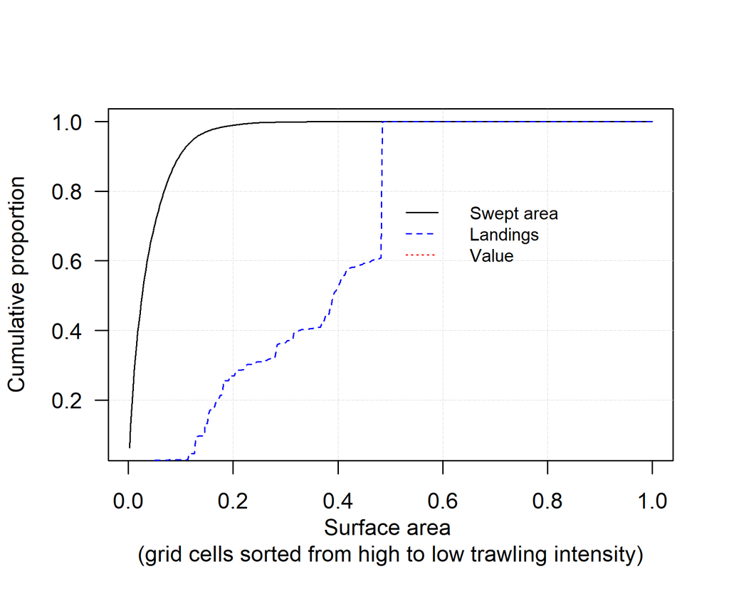

**Figure 4. Cumulative proportion of the swept area, landings and value. Grid cells were sorted from highest to lowest fishing intensity and include non-fished cells. The results are for all mobile bottom-contacting gears based on averaged fishing data per c-square from 2013-2018.**

### Core fishing grounds

No information available

### Fishing by métier

Intensity, weight and value of landings are estimated for the grid cells that were fished by one MBCG métier, ignoring cells fished by other métiers (Table 3).

#### Table 3

Table 3. Overview of area fished (sum of swept area), landings and value for the different metiers. Area fished in 1000 km2, weight of landings in 1000 tonnes, value of landings in 10^6 euro.

|  | DRB_MOL | OT_CRU | OT_DMF | OT_MI | OT_SPF | SDN_DMF | SSC_DMF | TBB_CRU | TBB_DMF | TBB_MOL |
| --- | --- | --- | --- | --- | --- | --- | --- | --- | --- | --- |
| Area swept (1000 km2) | <0.005 | 7.05 | 0.66 | 0 | 0 | 0 | 0 | 0 | 0 | 0 |
| Landings (1000 tonnes) | NA | NA | NA | NA | NA | NA | NA | NA | NA | NA |
| Value (10^6 euro) | NA | NA | NA | NA | NA | NA | NA | NA | NA | NA |
| Landings (1000 tonnes)/Area swept (1000 km2) | NA | NA | NA | NA | NA | NA | NA | NA | NA | NA |
| Value (10^6 euro)/Area swept (1000 km2) | NA | NA | NA | NA | NA | NA | NA | NA | NA | NA |

### Impact

No information available

### Management scenarios

No information available on value/weight of landings.

#### Overview all MSFD habitats

Fishing effort consequences, as a % relative to total swept area, of protecting a certain fraction of each broad habitat type sorted from low to high fished c-squares

| MSFD broad habitat type | Extent of habitat 1000 km<sup>2</sup> | 0.05 | 0.1 | 0.2 | 0.3 | 0.4 | 0.5 | 0.6 | 0.7 | 0.8 | 0.9 |
| --- | --- | --- | --- | --- | --- | --- | --- | --- | --- | --- | --- |
| Offshore circalittoral mud | 2.17 | 0.0 | <0.1 | <0.1 | 0.1 | 0.3 | 0.9 | 2.4 | 10.8 | 25.3 | 51.0 |
| Circalittoral mud | 2.31 | 0.0 | 0.0 | 0.0 | 0.0 | 0.0 | <0.1 | <0.1 | <0.1 | 0.2 | 2.5 |
| Circalittoral mixed sediment | 0.37 | 0.0 | 0.0 | 0.0 | <0.1 | <0.1 | <0.1 | 0.4 | 2.4 | 18.8 | 40.5 |
| Circalittoral sand | 2 | 0.0 | 0.0 | 0.0 | 0.0 | 0.0 | 0.0 | 0.0 | <0.1 | 0.1 | 7.6 |
| Circalittoral rock and biogenic reef | 0.17 | 0.0 | 0.0 | 0.0 | 0.0 | 0.0 | 0.0 | 0.0 | 0.0 | <0.1 | 13.3 |
| Offshore circalittoral mixed sediment | 0.07 | 0.1 | 0.3 | 1.4 | 4.2 | 5.8 | 9.2 | 12.8 | 18.5 | 34.4 | 50.8 |
| Offshore circalittoral sand | 0.65 | 0.0 | 0.0 | 0.0 | 0.0 | 0.0 | 0.7 | 8.2 | 11.6 | 23.3 | 41.1 |
| Offshore circalittoral rock and biogenic reef | 0.03 | 0.0 | 0.0 | 0.5 | 4.9 | 10.4 | 16.8 | 27.3 | 33.2 | 40.0 | 62.6 |
| Infralittoral sand | 0.89 | 0.0 | 0.0 | 0.0 | 0.0 | 0.0 | 0.0 | 0.0 | 0.0 | <0.1 | 3.8 |
| Upper bathyal sediment | 0.04 | 0.0 | 0.0 | 0.0 | 0.8 | 3.3 | 3.3 | 7.0 | 9.6 | 13.2 | 13.2 |
| Infralittoral mud | 0.19 | 0.0 | 0.0 | 0.0 | 0.0 | 0.0 | 0.0 | 0.0 | 0.7 | 15.8 | 47.0 |
| Infralittoral mixed sediment | 0.17 | 0.0 | 0.0 | 0.0 | 0.0 | 0.0 | 0.0 | 0.0 | 0.2 | 0.5 | 4.4 |
| Infralittoral rock and biogenic reef | 0.34 | 0.0 | 0.0 | 0.0 | 0.0 | 0.0 | 0.0 | 0.0 | 0.0 | 0.0 | 0.0 |
| Offshore circalittoral coarse sediment | 0.07 | 0.0 | 0.0 | 0.0 | 0.0 | 0.0 | 0.0 | 0.1 | 8.5 | 35.7 | 100.0 |
| Unknown | 0.01 | 0.0 | 0.0 | 0.0 | 1.6 | 1.6 | 38.2 | 38.2 | 38.2 | 38.2 | 100.0 |
| Infralittoral coarse sediment | 0.11 | 0.0 | 0.0 | 0.0 | 0.0 | 0.0 | 0.0 | 0.0 | 0.0 | 0.0 | 0.0 |
| Circalittoral coarse sediment | 0.1 | 0.0 | 0.0 | 0.0 | 0.0 | 0.0 | 0.0 | 0.0 | 0.0 | 0.0 | <0.1 |
| Upper bathyal rock and biogenic reef | 0 | NaN | NaN | NaN | NaN | NaN | NaN | NaN | NaN | NaN | NaN |

## Southern area deep

### Summary

The physical disturbance pressures from mobile bottom-contacting fishing gears varies spatially in the “Southern area deep” subdivision with 74% of the grid cells (I-2), and 44% of the surface area (I-3) in areas at depths from 200 to 800m being fished on average per year for the period 2013-2018 (Table 1). Fishing is very aggregated with 90% of the pressure occurring in only 28% of grid cells (I-4). There is very little fishing beyond 800m depth.

The ICES methods for computing impact are not available in the region and therefore this part of the analysis has not been completed.

Maps of spatial distribution of intensity, seafloor sensitivity and economic value and weight of fisheries landings are shown in Figure 1. It is evident from the weight map that there is a mistake in the weights for the region, and weights are not presented in further analyses.

#### Table 1

Table 1. Pressure and impact indicators for 2013-2018

| Indicators | 0 to 200 m | 200 to 800 m | more than 800 m |
| --- | --- | --- | --- |
| Average intensity (I-1) | NA | 1.84 | 0.01 |
| Proportion of area in fished cells (I-2) | NA | 0.74 | 0.03 |
| Proportion of area fished per year (I-3) | NA | 0.44 | 0.00 |
| Smallest prop. of area in fished cells with 90% of fishing effort (I-4) | NA | 0.28 | 0.01 |
| Proportion of area in unfished cells (I-5) | NA | 0.26 | 0.97 |
| Average PD impact (I-6) | NA | NA | NA |
| Average L1 impact (I-6) | NA | NA | NA |
| Proportion of area with PD impact < 0.2 (I-7) | NA | NA | NA |
| Proportion of area with L1 impact < 0.2 (I-7) | NA | NA | NA |

#### Figure 1

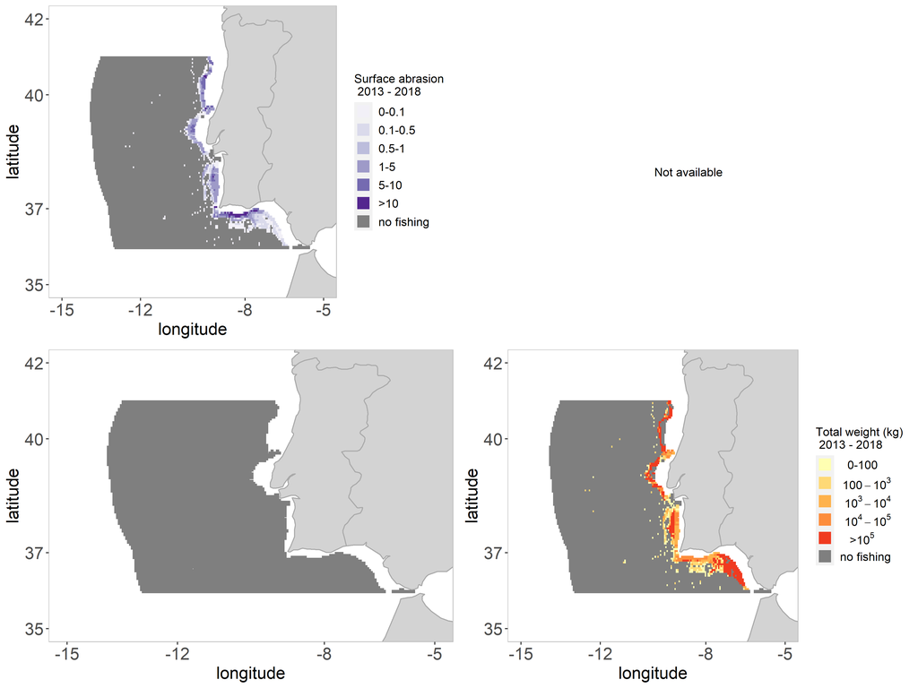

**Figure 1 Geographic distribution of surface abrasion, seabed sensitivity (not shown) and total value and weight from mobile bottom-contacting gear. The maps of surface abrasion, value and weight show the average per year for 2013-2018**